# Should This Loan be Approved or Not?

Yuying(Jean) Dong

# Contents

Introduction  
Data  
Models  
Summary

# Introduction

The dataset is from the U.S. Small Business Administration (SBA)

The U.S. SBA was founded in 1953 on the principle of promoting and assisting small enterprises in the U.S. credit market (SBA Overview and History, US Small Business Administration (2015)). Small businesses have been a primary source of job creation in the United States; therefore, fostering small business formation and growth has social benefits by creating job opportunities and reducing unemployment.

There have been many success stories of start-ups receiving SBA loan guarantees such as FedEx and Apple Computer. However, there have also been stories of small businesses and/or start-ups that have defaulted on their SBA-guaranteed loans.

Retrieved from https://www.kaggle.com/mirbektoktogaraev/should-this-loan-be-approved-or-denied

Table 1. Description of 27 variables in both datasets

| Variable | Data type | Description of variable |
| --- | --- | --- |
| LoanNr_ChkDgt | Text | Identifier - Primary key |
| Name | Text | Borrower name |
| City | Text | Borrower city |
| State | Text | Borrower state |
| Zip | Text | Borrower zip code |
| Bank | Text | Bank name |
| BankState | Text | Bank state |
| NAICS | Text | North American industry classification system code |
| ApprovalDate | Date/Time | Date SBA commitment issued |
| ApprovalFY | Text | Fiscal year of commitment |
| Term | Number | Loan term in months |
| NoEmp | Number | Number of business employees |
| NewExist | Text | 1 = Existing business, 2 = New businesss |
| CreateJob | Number | Number of jobs created |
| RetainedJob | Number | Number of jobs retained |
| FranchiseCode | Text | Franchise code, (00000 or 00001) = No franchise |
| UrbanRural | Text | 1 = Urban, 2 = rural, 0 = undefined |
| RevLineCr | Text | Revolving line of credit: Y = Yes, N = No |
| LowDoc | Text | LowDoc Loan Program: Y = Yes, N = No |
| ChgOffDate | Date/Time | The date when a loan is declared to be in default |
| DisbursementDate | Date/Time | Disbursement date |
| DisbursementGross | Currency | Amount disbursed |
| BalanceGross | Currency | Gross amount outstanding |
| MIS_Status | Text | Loan status charged off = CHGOFF,Paid in full = PIF |
| ChgOffPrinGr | Currency | Charged-off amount |
| GrAppv | Currency | Gross amount of loan approved by bank |
| SBA_Appv | Currency | SBA's guaranteed amount of approved loan |

## Import Standard Packages and Data Set

```python
import numpy as np
import matplotlib.pyplot as plt
import pandas as pd
import seaborn as sn
import matplotlib.pyplot as plt
import seaborn as sns
#From Scikit Learn
from sklearn import preprocessing
from sklearn.model_selection  import train_test_split, cross_val_score, KFold
from sklearn.model_selection import GridSearchCV
from sklearn.metrics import accuracy_score, precision_score, recall_score, f1_score
from sklearn.metrics import roc_curve, auc, confusion_matrix, classification_report
```

```python
pathway = "...data/"
```

```python
sba = pd.read_csv(pathway + "SBAnational.csv")
```

# Data

### Clean and Explore The Data

Take a look at the data we will work with.

```python
print(sba.shape)
```

```
(899164, 27)
```

The dataset has 899164 rows and 27 rows.

```python
sba.head()
```

|  | LoanNr_ChkDgt | Name | City | State | Zip | Bank | BankState | NAICS | ApprovalDate | ApprovalFY | ... | RevLineCr | LowDoc | ChgOffDate | DisbursementDate | DisbursementGross | BalanceGross | MIS_Status | ChgOffPrinGr | GrAppv | SBA_Appv |
| --- | --- | --- | --- | --- | --- | --- | --- | --- | --- | --- | --- | --- | --- | --- | --- | --- | --- | --- | --- | --- | --- |
| 0 | 1000014003 | ABC HOBBYCRAFT | EVANSVILLE | IN | 47711 | FIFTH THIRD BANK | OH | 451120 | 28-Feb-97 | 1997 | ... | N | Y | NaN | 28-Feb-99 | $60,000.00 | $0.00 | P I F | $0.00 | $60,000.00 | $48,000.00 |
| 1 | 1000024006 | LANDMARK BAR & GRILLE (THE) | NEW PARIS | IN | 46526 | 1ST SOURCE BANK | IN | 722410 | 28-Feb-97 | 1997 | ... | N | Y | NaN | 31-May-97 | $40,000.00 | $0.00 | P I F | $0.00 | $40,000.00 | $32,000.00 |
| 2 | 1000034009 | WHITLOCK DDS, TODD M. | BLOOMINGTON | IN | 47401 | GRANT COUNTY STATE BANK | IN | 621210 | 28-Feb-97 | 1997 | ... | N | N | NaN | 31-Dec-97 | $287,000.00 | $0.00 | P I F | $0.00 | $287,000.00 | $215,250.00 |
| 3 | 1000044001 | BIG BUCKS PAWN & JEWELRY, LLC | BROKEN ARROW | OK | 74012 | 1ST NATL BK & TR CO OF BROKEN | OK | 0 | 28-Feb-97 | 1997 | ... | N | Y | NaN | 30-Jun-97 | $35,000.00 | $0.00 | P I F | $0.00 | $35,000.00 | $28,000.00 |
| 4 | 1000054004 | ANASTASIA CONFECTIONS, INC. | ORLANDO | FL | 32801 | FLORIDA BUS. DEVEL CORP | FL | 0 | 28-Feb-97 | 1997 | ... | N | N | NaN | 14-May-97 | $229,000.00 | $0.00 | P I F | $0.00 | $229,000.00 | $229,000.00 |

5 rows × 27 columns

Above shows the first five rows.

```python
sba.tail()
```

|  | LoanNr_ChkDgt | Name | City | State | Zip | Bank | BankState | NAICS | ApprovalDate | ApprovalFY | ... | RevLineCr | LowDoc | ChgOffDate | DisbursementDate | DisbursementGross | BalanceGross | MIS_Status | ChgOffPrinGr | GrAppv | SBA_Appv |
| --- | --- | --- | --- | --- | --- | --- | --- | --- | --- | --- | --- | --- | --- | --- | --- | --- | --- | --- | --- | --- | --- |
| 899159 | 9995573004 | FABRIC FARMS | UPPER ARLINGTON | OH | 43221 | JPMORGAN CHASE BANK NATL ASSOC | IL | 451120 | 27-Feb-97 | 1997 | ... | 0 | N | NaN | 30-Sep-97 | $70,000.00 | $0.00 | P I F | $0.00 | $70,000.00 | $56,000.00 |
| 899160 | 9995603000 | FABRIC FARMS | COLUMBUS | OH | 43221 | JPMORGAN CHASE BANK NATL ASSOC | IL | 451130 | 27-Feb-97 | 1997 | ... | Y | N | NaN | 31-Oct-97 | $85,000.00 | $0.00 | P I F | $0.00 | $85,000.00 | $42,500.00 |
| 899161 | 9995613003 | RADCO MANUFACTURING CO.,INC. | SANTA MARIA | CA | 93455 | RABOBANK, NATIONAL ASSOCIATION | CA | 332321 | 27-Feb-97 | 1997 | ... | N | N | NaN | 30-Sep-97 | $300,000.00 | $0.00 | P I F | $0.00 | $300,000.00 | $225,000.00 |
| 899162 | 9995973006 | MARUTAMA HAWAII, INC. | HONOLULU | HI | 96830 | BANK OF HAWAII | HI | 0 | 27-Feb-97 | 1997 | ... | N | Y | 8-Mar-00 | 31-Mar-97 | $75,000.00 | $0.00 | CHGOFF | $46,383.00 | $75,000.00 | $60,000.00 |
| 899163 | 9996003010 | PACIFIC TRADEWINDS FAN & LIGHT | KAILUA | HI | 96734 | CENTRAL PACIFIC BANK | HI | 0 | 27-Feb-97 | 1997 | ... | N | N | NaN | 31-May-97 | $30,000.00 | $0.00 | P I F | $0.00 | $30,000.00 | $24,000.00 |

5 rows × 27 columns

Above shows the last five rows,

```python
sba.isna().sum()
```

```
LoanNr_ChkDgt             0
Name                     14
City                     30
State                    14
Zip                       0
Bank                   1559
BankState              1566
NAICS                     0
ApprovalDate              0
ApprovalFY                0
Term                      0
NoEmp                     0
NewExist                136
CreateJob                 0
RetainedJob               0
FranchiseCode             0
UrbanRural                0
RevLineCr              4528
LowDoc                 2582
ChgOffDate           736465
DisbursementDate       2368
DisbursementGross         0
BalanceGross              0
MIS_Status             1997
ChgOffPrinGr              0
GrAppv                    0
SBA_Appv                  0
dtype: int64
```

The "0" means there is no null value in the row, the values except "0" means there are null values exist in the rows. The ChgOffDate has 736465 null values. As the ChgOffDate not important for loan prediction. This feature may need to be drop off later.

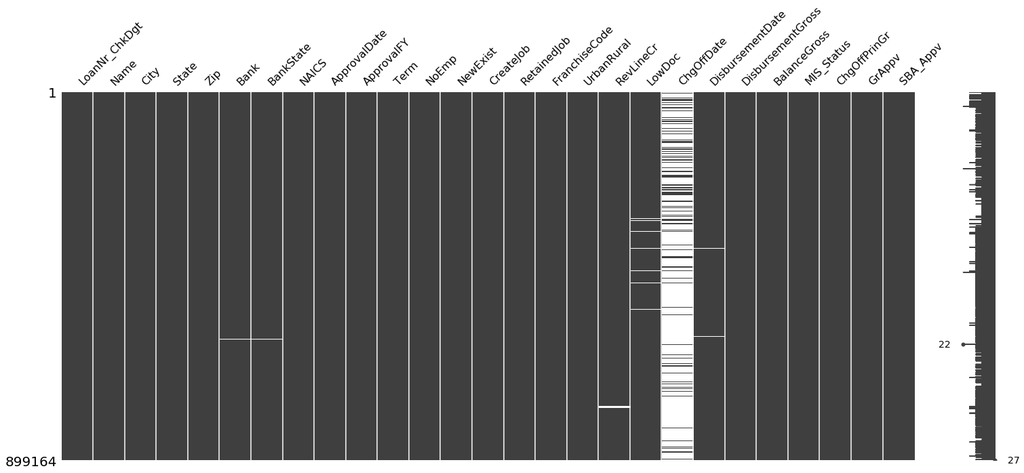

```python
import missingno as msno
import matplotlib.pyplot as plt
# Visualize missingness
msno.matrix(sba)
plt.show()
```

This graph shows the null values in white color. We can see that the column ChgOffDate is almost white.

```python
sba.drop('ChgOffDate',axis=1)
print("The shape of SBA", sba.shape)
print(sba.columns)
```

```
The shape of SBA (899164, 27)
Index(['LoanNr_ChkDgt', 'Name', 'City', 'State', 'Zip', 'Bank', 'BankState',
       'NAICS', 'ApprovalDate', 'ApprovalFY', 'Term', 'NoEmp', 'NewExist',
       'CreateJob', 'RetainedJob', 'FranchiseCode', 'UrbanRural', 'RevLineCr',
       'LowDoc', 'ChgOffDate', 'DisbursementDate', 'DisbursementGross',
       'BalanceGross', 'MIS_Status', 'ChgOffPrinGr', 'GrAppv', 'SBA_Appv'],
      dtype='object')
```

```python
sba.dropna(subset=['Name', 'City', 'State', 'BankState', 'NewExist','RevLineCr', 'LowDoc',
                   'DisbursementDate', 'MIS_Status'], inplace=True)
sba.isna().sum()
```

```
LoanNr_ChkDgt             0
Name                      0
City                      0
State                     0
Zip                       0
Bank                      0
BankState                 0
NAICS                     0
ApprovalDate              0
ApprovalFY                0
Term                      0
NoEmp                     0
NewExist                  0
CreateJob                 0
RetainedJob               0
FranchiseCode             0
UrbanRural                0
RevLineCr                 0
LowDoc                    0
ChgOffDate           725369
DisbursementDate          0
DisbursementGross         0
BalanceGross              0
MIS_Status                0
ChgOffPrinGr              0
GrAppv                    0
SBA_Appv                  0
dtype: int64
```

```python
print(sba.shape)
```

```
(886240, 27)
```

```python
sba.dtypes
```

```
LoanNr_ChkDgt          int64
Name                  object
City                  object
State                 object
Zip                    int64
Bank                  object
BankState             object
NAICS                  int64
ApprovalDate          object
ApprovalFY            object
Term                   int64
NoEmp                  int64
NewExist             float64
CreateJob              int64
RetainedJob            int64
FranchiseCode          int64
UrbanRural             int64
RevLineCr             object
LowDoc                object
ChgOffDate            object
DisbursementDate      object
DisbursementGross     object
BalanceGross          object
MIS_Status            object
ChgOffPrinGr          object
GrAppv                object
SBA_Appv              object
dtype: object
```

Check the data types. The data types of Zip, NewExist, DisbursementGross, BalanceGross, ChgOffPrinGr, GrAppv, SBA_Appv are wired. The tupes of these columns should be numeric. We will look into the data to see the reason.

First, clean the DisbursementGross, BalanceGross, ChgOffPrinGr, GrAppv, SBA_Appv columns.

```python
sba.DisbursementGross.head()
```

```
0     $60,000.00
1     $40,000.00
2    $287,000.00
3     $35,000.00
4    $229,000.00
Name: DisbursementGross, dtype: object
```

```python
sba.BalanceGross.head()
```

```
0    $0.00
1    $0.00
2    $0.00
3    $0.00
4    $0.00
Name: BalanceGross, dtype: object
```

```python
sba.ChgOffPrinGr.head()
```

```
0    $0.00
1    $0.00
2    $0.00
3    $0.00
4    $0.00
Name: ChgOffPrinGr, dtype: object
```

```python
sba.GrAppv.head()
```

```
0     $60,000.00
1     $40,000.00
2    $287,000.00
3     $35,000.00
4    $229,000.00
Name: GrAppv, dtype: object
```

```python
sba.SBA_Appv.head()
```

```
0     $48,000.00
1     $32,000.00
2    $215,250.00
3     $28,000.00
4    $229,000.00
Name: SBA_Appv, dtype: object
```

We can see the datas has dollar sign and , sign at the begining. This may be the reason for the data type. Remove the dollar sign and , sign with the code below.

```python
sba['DisbursementGross'] = sba['DisbursementGross'].str.replace('$','')
sba['DisbursementGross'] = sba['DisbursementGross'].str.replace(',','')
```

```python
sba['BalanceGross'] = sba['BalanceGross'].str.replace('$','')
sba['BalanceGross'] = sba['BalanceGross'].str.replace(',','')
```

```python
sba['ChgOffPrinGr'] = sba['ChgOffPrinGr'].str.replace('$','')
sba['ChgOffPrinGr'] = sba['ChgOffPrinGr'].str.replace(',','')
```

```python
sba['GrAppv'] = sba['GrAppv'].str.replace('$','')
sba['GrAppv'] = sba['GrAppv'].str.replace(',','')
```

```python
sba['SBA_Appv'] = sba['SBA_Appv'].str.replace('$','')
sba['SBA_Appv'] = sba['SBA_Appv'].str.replace(',','')
```

```python
sba.DisbursementGross.head(1)
```

```
0    60000.00
Name: DisbursementGross, dtype: object
```

```python
sba.BalanceGross.head(1)
```

```
0    0.00
Name: BalanceGross, dtype: object
```

```python
sba.ChgOffPrinGr.head(1)
```

```
0    0.00
Name: ChgOffPrinGr, dtype: object
```

```python
sba.GrAppv.head(1)
```

```
0    60000.00
Name: GrAppv, dtype: object
```

```python
sba.SBA_Appv.head(1)
```

```
0    48000.00
Name: SBA_Appv, dtype: object
```

Check through the data to see if any adjustment needed.

```python
sba['LoanNr_ChkDgt'].unique()
```

```
array([1000014003, 1000024006, 1000034009, ..., 9995613003, 9995973006,
       9996003010], dtype=int64)
```

```python
sba['Name'].unique()
```

```
array(['ABC HOBBYCRAFT', 'LANDMARK BAR & GRILLE (THE)',
       'WHITLOCK DDS, TODD M.', ..., 'RADCO MANUFACTURING CO.,INC.',
       'MARUTAMA HAWAII, INC.', 'PACIFIC TRADEWINDS FAN & LIGHT'],
      dtype=object)
```

```python
sba['City'].unique()
```

```
array(['EVANSVILLE', 'NEW PARIS', 'BLOOMINGTON', ..., 'MURFRECSBORO',
       'E WENALCHEE', 'SO. OZONE PARK'], dtype=object)
```

```python
sba['State'].unique()
```

```
array(['IN', 'OK', 'FL', 'CT', 'NJ', 'NC', 'IL', 'RI', 'TX', 'VA', 'TN',
       'AR', 'MN', 'MO', 'MA', 'CA', 'SC', 'LA', 'IA', 'OH', 'KY', 'MS',
       'NY', 'MD', 'PA', 'OR', 'ME', 'KS', 'MI', 'AK', 'WA', 'CO', 'MT',
       'WY', 'UT', 'NH', 'WV', 'ID', 'AZ', 'NV', 'WI', 'NM', 'GA', 'ND',
       'VT', 'AL', 'NE', 'SD', 'HI', 'DE', 'DC'], dtype=object)
```

```python
sba['Zip'].unique()
```

```
array([47711, 46526, 47401, ..., 70036, 66549, 26134], dtype=int64)
```

```python
sba['Bank'].unique()
```

```
array(['FIFTH THIRD BANK', '1ST SOURCE BANK', 'GRANT COUNTY STATE BANK',
       ..., 'FIRST ILLINOIS BANK', 'COLORADO COMMUNITY FIRST STATE',
       'DEPCO'], dtype=object)
```

```python
sba['BankState'].unique()
```

```
array(['OH', 'IN', 'OK', 'FL', 'DE', 'SD', 'AL', 'CT', 'GA', 'OR', 'MN',
       'RI', 'NC', 'TX', 'MD', 'NY', 'TN', 'SC', 'MS', 'MA', 'LA', 'IA',
       'VA', 'CA', 'IL', 'KY', 'PA', 'MO', 'WA', 'MI', 'UT', 'KS', 'WV',
       'WI', 'AZ', 'NJ', 'CO', 'ME', 'NH', 'AR', 'ND', 'MT', 'ID', 'WY',
       'NM', 'DC', 'NV', 'NE', 'PR', 'HI', 'VT', 'AK', 'GU', 'AN', 'EN',
       'VI'], dtype=object)
```

According to the PDF file attached, NAICS refers to the North American idustry classification system code. Table 2. Description of the first two digits of NAICS.

| Sector | Description |
| --- | --- |
| 11 | Agriculture, forestry, fishing and hunting |
| 21 | Mining, quarrying, and oil and gas extraction |
| 22 | Utilities |
| 23 | Construction |
| 31-33 | Manufacturing |
| 42 | Wholesale trade |
| 44-45 | Retail trade |
| 48-49 | Transportation and warehousing |
| 51 | Information |
| 52 | Finance and insurance |
| 53 | Real estate and rental and leasing |
| 54 | Professional, scientific, and technical services |
| 55 | Manangement of companies and enterprises |
| 56 | Administrative and support and waste management and remediation services |
| 61 | Educational services |
| 62 | Health care and social assistance |
| 71 | Arts, entertainment, and recreation |
| 72 | Accommodation and food services |
| 81 | Other services (except public administration) |
| 92 | Public administration |

```python
sba['NAICS'].unique()
```

```
array([451120, 722410, 621210, ..., 315280, 922140, 221121], dtype=int64)
```

Check the NAICS column. These are 6 digits numbers, we only need the first two digits to assign industry. We will use dictionary to assign the industry in a new column.

With the code below, we store the first 2 digits in a new column named Industry.

```python
sba['Industry'] = sba['NAICS'].astype('str').apply(lambda x: x[:2])
```

```python
#Then, we use dictionary to replace the e digits with industry.
sba['Industry'] = sba['Industry'].map({'11': 'Ag/For/Fish/Hunt', '21': 'Min/Quar/Oil_Gas_ext',
                                               '22': 'Utilities', '23': 'Construction', '31': 'Manufacturing',
                                               '32': 'Manufacturing', '33': 'Manufacturing', '42': 'Wholesale_trade',
                                               '44': 'Retail_trade', '45': 'Retail_trade', '48': 'Trans/Ware',
                                               '49': 'Trans/Ware', '51': 'Information', '52': 'Finance/Insurance',
                                               '53': 'RE/Rental/Lease', '54': 'Prof/Science/Tech', '55': 'Mgmt_comp',
                                               '56': 'Admin_sup/Waste_Mgmt_Rem', '61': 'Educational',
                                               '62': 'Healthcare/Social_assist', '71': 'Arts/Entertain/Rec',
                                               '72': 'Accom/Food_serv', '81': 'Other_no_pub', '92': 'Public_Admin'})
```

Check the null values to see if the dictionary function generate new null values.

```python
sba.isna().sum()
```

```
LoanNr_ChkDgt             0
Name                      0
City                      0
State                     0
Zip                       0
Bank                      0
BankState                 0
NAICS                     0
ApprovalDate              0
ApprovalFY                0
Term                      0
NoEmp                     0
NewExist                  0
CreateJob                 0
RetainedJob               0
FranchiseCode             0
UrbanRural                0
RevLineCr                 0
LowDoc                    0
ChgOffDate           725369
DisbursementDate          0
DisbursementGross         0
BalanceGross              0
MIS_Status                0
ChgOffPrinGr              0
GrAppv                    0
SBA_Appv                  0
Industry             198267
dtype: int64
```

```python
sba.dropna(subset=['Industry'], inplace=True)
sba.isna().sum()
```

```
LoanNr_ChkDgt             0
Name                      0
City                      0
State                     0
Zip                       0
Bank                      0
BankState                 0
NAICS                     0
ApprovalDate              0
ApprovalFY                0
Term                      0
NoEmp                     0
NewExist                  0
CreateJob                 0
RetainedJob               0
FranchiseCode             0
UrbanRural                0
RevLineCr                 0
LowDoc                    0
ChgOffDate           544089
DisbursementDate          0
DisbursementGross         0
BalanceGross              0
MIS_Status                0
ChgOffPrinGr              0
GrAppv                    0
SBA_Appv                  0
Industry                  0
dtype: int64
```

The null value in Industry has been removed.

we continue to check the other column values.

```python
sba['ApprovalDate'].unique()
```

```
array(['28-Feb-97', '7-Feb-06', '25-Mar-97', ..., '25-Feb-97',
       '26-Feb-97', '27-Feb-97'], dtype=object)
```

```python
sba['ApprovalFY'].unique()
```

```
array([1997, 2006, 1998, 1999, 2000, 2001, 2003, 2004, 2005, 1984, 2007,
       1987, 2008, 1988, 2009, 1989, 1990, 2010, 1991, 2011, 1992, 2002,
       2012, 1993, 2013, 1994, 2014, '2004', '1994', '1995', '2005',
       '1996', 1996], dtype=object)
```

We can see the ApprovalFY has many error data.

Use a function to clean the A in ApprovalFY.

```python
def function(i):
    if isinstance(i, str):
        return i.replace('A', '')
    return i
sba['ApprovalFY'] = sba['ApprovalFY'].apply(function)
```

```python
sba['ApprovalFY'].unique()
```

```
array([1997, 2006, 1998, 1999, 2000, 2001, 2003, 2004, 2005, 1984, 2007,
       1987, 2008, 1988, 2009, 1989, 1990, 2010, 1991, 2011, 1992, 2002,
       2012, 1993, 2013, 1994, 2014, '2004', '1994', '1995', '2005',
       '1996', 1996], dtype=object)
```

Change the data types with the code below.

```python
sba = sba.astype({'Zip': 'str', 'NewExist': 'int64', 'UrbanRural': 'str',
                  'DisbursementGross': 'float', 'BalanceGross': 'float',
                  'ChgOffPrinGr': 'float', 'GrAppv': 'float', 'SBA_Appv': 'float'})
```

Check the data types to make sure the code works.

```python
sba.dtypes
```

```
LoanNr_ChkDgt          int64
Name                  object
City                  object
State                 object
Zip                   object
Bank                  object
BankState             object
NAICS                  int64
ApprovalDate          object
ApprovalFY            object
Term                   int64
NoEmp                  int64
NewExist               int64
CreateJob              int64
RetainedJob            int64
FranchiseCode          int64
UrbanRural            object
RevLineCr             object
LowDoc                object
ChgOffDate            object
DisbursementDate      object
DisbursementGross    float64
BalanceGross         float64
MIS_Status            object
ChgOffPrinGr         float64
GrAppv               float64
SBA_Appv             float64
Industry              object
dtype: object
```

Continue to check the other columns.

```python
sba['Term'].unique()
```

```
array([ 84,  60, 180, 120, 297, 162,  12,  87, 126,  83, 240, 102,  80,
        42, 167,   7,  36,  26, 264,   5,  54,  66,   4,  96,  93, 288,
       300, 108,  90,   3,  27,  41,  57, 104,  82,  14,  58,  32,  72,
        48,  31, 112,  73,  11,  15,  79,  53, 255,  55, 133,  95,  35,
        62,  68,   6, 123,  46,  70,  52,  65,  47,  91,  59,   1,  74,
        49,  77,  16, 114,  86,  63,  56,  10,  22,   0,  97,  40,  23,
        17,  69,  21,  43,  89,  92, 183,   2,  34,   9,  78,  18, 129,
       216,   8,  29,  45, 289,  30,  37,  39,  24,  13, 119, 228, 276,
       208,  44,  81,  85,  38,  51, 144, 103,  25,  64, 111, 266,  75,
       306,  28, 117, 118, 309, 303,  71,  98, 116,  76, 113, 191,  19,
        61,  99,  88, 166, 176, 258, 168,  94, 231, 142,  33, 157, 165,
        50, 106,  20, 318, 229, 204, 269, 241, 115, 174,  67, 100, 131,
       134, 141, 246, 122, 292, 282, 156, 125, 268, 294, 238, 124, 279,
       186, 190, 192, 128, 147, 302, 299, 280, 202, 301, 101, 121, 107,
       278, 272, 243, 283, 250, 290, 252, 187, 310, 136, 261, 196, 249,
       175, 139, 110, 270, 277, 304, 150, 207, 213, 177, 273, 132, 215,
       158, 189, 222, 164, 262, 193, 137, 146, 308, 155, 311, 135, 185,
       307, 149, 105, 181, 109, 265, 210, 349, 206, 251, 145, 152, 230,
       285, 201, 169, 171, 227, 195, 127, 163, 143, 160, 217, 298, 140,
       236, 159, 247, 256, 153, 199, 253, 148, 198, 237, 220, 244, 138,
       223, 239, 218, 312, 284, 281, 257, 274, 182, 212, 154, 161, 203,
       305, 209, 179, 219, 184, 263, 205, 248, 178, 197, 291, 234, 188,
       130, 225, 194, 173, 151, 295, 242, 224, 200, 172, 267, 286, 245,
       296, 275, 233, 334, 260, 340, 320, 170, 271, 315, 259, 226, 232,
       360, 214, 221, 316, 254, 235, 211, 321, 287, 293, 330, 325, 314,
       404, 324, 365, 313, 319, 336, 329, 317, 350, 335, 369, 357, 355,
       362, 322, 359, 358, 341, 323, 326, 333, 372, 348, 356, 396, 382,
       364, 385, 367, 374, 354, 353, 527, 370, 327, 569, 366, 339, 428,
       346, 388, 386, 409, 445, 449, 389, 434, 328, 423, 440, 429, 347,
       391], dtype=int64)
```

This column looks normal.

```python
sba['NoEmp'].unique()
```

```
array([   4,    2,    7,   19,    1,   24,    5,   18,   12,    3,    9,
         10,    8,   20,   16,    6,   50,   60,   40,   72,   55,   32,
         22,  214,   45,   14,   28,   11,   15,   30,  112,   23,   80,
         42,   17,   65,   25,   97,   46,   13,  200,   31,  126,   33,
         58,   38,    0,   75,   36,   21,   35,   66,   27, 2000,   56,
         34,   26,   93,   85,  150,   29,   41,  100,   54,  300,   49,
        120,  265,  133,  160,   70,   68,   48,   61,  220,   43,   39,
         71,   44,   78,  233,  263,   62,   63,  210,  450,   86,   90,
        165,  130,  350, 9992,   77,  424,   51,  190,   52,   47,   74,
        250,   69,   37,  140,  260,  339,   87,   73,  110,  161,   59,
         88,  105,  116,   53,  400,   67,   96,  605,  125,   57,  103,
         95,   81,   82,   64,   94,  144,  175,  155,  345,   98,  121,
        216,  108,  138,  117,  118,  171,  170,  145,  115,  119,  900,
        180,   79,  127,  205,  128,  102,   91,   89,  600,  576,  196,
        135,  101,  129,  141,  142,  320,   84,  162, 4000,  104,  114,
```

[output cut: 31 more lines]

This column looks normal.

```python
sba['NewExist'].unique()
```

```
array([2, 1, 0], dtype=int64)
```

In Table 1, the NewExist do not has description for 0.

```python
sba.groupby('NewExist').size()
```

```
NewExist
0       727
1    496618
2    190628
dtype: int64
```

After check the count by group, the NewExist=0 should be removed.

```python
sba = sba[sba.NewExist != 0]
```

```python
sba.groupby('NewExist').size()
```

```
NewExist
1    496618
2    190628
dtype: int64
```

```python
sba.shape
```

```
(687246, 28)
```

The 0 values in column NewExist has been removed. However, 1 = Existing business, 2 = New business, as the column name is NewExist, it is better to set 0 = Existing business, 1 = New business. So I changed the column value with the code below.

```python
sba['NewExist'] = sba['NewExist'].replace([1,2],[0,1])
```

```python
sba.groupby('NewExist').size()
```

```
NewExist
0    496618
1    190628
dtype: int64
```

The values in column NewExist has been changed to 0 = Existing business, 1 = New business,

```python
sba['CreateJob'].unique()
```

```
array([   0,    5,    4,    1,   20,    3,    8,   16,   15,   11,    2,
         40,    7,   10,   55,   25,    6,   12,    9,   13,   47,   18,
         17,   30,   29,   23,   50,   35,   14,   43,   22,   45,   19,
         58,   48,   72,   38,   28,   24,  150,   21,   82,   41,   80,
         70,   33,   27,   97,   32,   34,   36,   60,  200,   26,   90,
         77,   75,   31,  100,   99,   44,  120,   69,   95,   42,  160,
         37,  600, 1000,   39,   53,   49,   54,   85,   59,   65,  450,
        456,  452,  451,  198,   79,  454,  136,   64,   74,   63,   78,
         98,  455,   76,  152,   84,   51, 2020,  225,  110,  453,  125,
        458,  457,  174,   52,   46,  104,   89,  320,  154,  300,  102,
        149,  180,  153,  800,   62,  130,  235,  250,  137,  500,   57,
         96,  360,   56,  140,  122,  175, 1200,   66,  112,  118,  220,
        115,   73,  151,  195,   67,  138,  400,   61,  124,   91, 1711,
        105,  131,  409, 1618, 1150,  157,  166,  135,  210,  252,  116,
         71,  129,   81,  569,  144,   68, 1011,  179,   83,  146,  171,
        141,  126,   92,  101,  119,  280,  123, 1229,  128,  103,  114,
        108,  221,  167,   87,   88,  186,  750,   86,  139,  206,  375,
        109,  177,  264,  168, 3000,  240, 5621,  121,  145,  170,  169,
        165,  222,  106,  148,  363, 1118,  310,  164, 5085,  143,  480,
        256,  365,  155,  397,  270,   94,  162, 1016], dtype=int64)
```

The CreateJob looks normal.

```python
sba['RetainedJob'].unique()
```

```
array([   0,   23,    4,    6,    1,    9,   20,    2,    5,   19,    8,
          3,   10,   24,   12,    7,   15,   11,   25,   44,   17,   14,
         65,   28,   38,   26,   18,   13,   50,   93,   40,   60,   21,
         31,   34,   35,  150,   16,   30,   41,   45,   37,  100,  180,
         58,  165,   36,  130,   29,   75,   27,   22,   46,   32,  257,
         43,   42,   47,   80,   70,   62,   33,  400,  125,   55,   95,
         48,  120,   71,   81,   52,   94,   78,  160,  109,   77,  155,
         39,   85,   90,   54,   64, 3225,   61,   69,   66,  210,  107,
         97,   51,   83,   63,  112,   53,   76,   87,   68,  118,  138,
         67,   57,   56,  117,  171,  115,  300,  140,  105,   59,   79,
        205,  206,  128,  250,   89,   72,   49,  135,   92,   86,  404,
        200,  110,  320,  139,   82,  108,   88,  104,  114,  230,  102,
         98,  101,   84,  220,   74,  267,   91, 9500,  175,  550,  500,
        450,   73,  170,  275,  123,  195,  116,   99,  610,   96,  187,
        235,  157,  124,  137,  127,  106,  254, 4441,  277,  225,  111,
        317,  173,  350,  143,  430,  197,  176,  145,  133,  256, 2200,
        362,  202,  148,  316,  215,  146,  185,  154,  212,  141,  163,
        132,  194,  113,  161,  172,  330,  366,  190, 1300,  390,  103,
       3900,  967,  147,  121,  240,  162,  523,  159, 1711,  119,  251,
        152,  417,  207,  291,  153,  131,  544,  129,  142,  231,  189,
        126,  203,  360,  213,  280,  484,  260,  177,  281,  675,  700,
        247,  600,  245,  750,  151,  270,  191,  182,  342,  217,  232,
        287,  136,  285,  188,  375, 1700,  122,  134,  660,  156,  318,
        265,  167,  214,  216,  236,  370,  310,  322,  208,  515,  259,
        328,  263,  497,  356,  255,  158,  192,  166,  219,  186,  363,
        274,  169,  144,  262,  315,  178,  420,  223,  184,  585,  325,
        710,  196,  237,  940,  302,  394, 3860,  244,  410,  720,  252,
        290,  297,  548,  485,  183,  800,  149,  387,  298,  480,  266,
        164,  403,  498,  448,  535,  168,  327,  911,  229,  540,  304,
       1111,  243,  198], dtype=int64)
```

The RetainedJob looks normal.

```python
sba['FranchiseCode'].unique()
```

```
array([    1, 15100, 10656, ..., 16452, 35618, 18701], dtype=int64)
```

As in Franchise code, (00000 or 00001) = No franchise. So it's better to seperate the FranchiseCode into 0 = No franchise and 1 = Franchise.

```python
# Code borrowed from https://pandas.pydata.org/pandas-docs/stable/reference/api/pandas.DataFrame.loc.html
sba.loc[(sba['FranchiseCode'] <= 1),['FranchiseCode']] = 0
sba.loc[(sba['FranchiseCode'] > 1),['FranchiseCode']] = 1
sba['FranchiseCode'].unique()
```

```
array([0, 1], dtype=int64)
```

The FranchiseCode has been seperate the FranchiseCode into 0 = No franchise and 1 = Franchise.

```python
sba['UrbanRural'].unique()
```

```
array(['0', '1', '2'], dtype=object)
```

```python
sba.groupby('UrbanRural').size()
```

```
UrbanRural
0    141334
1    445640
2    100272
dtype: int64
```

The UrbanRural column looks normal.

Revolving line of credit: Y = Yes, N = No

```python
sba['RevLineCr'].unique()
```

```
array(['N', 'Y', '0', 'T', '`', ',', '1', 'C', '2', 'R', '7', 'A', '-',
       'Q'], dtype=object)
```

```python
sba.groupby('RevLineCr').size()
```

```
RevLineCr
,         1
-         1
0    213984
1        14
2         5
7         1
A         1
C         2
N    266602
Q         1
R        14
T     14487
Y    192128
`         5
dtype: int64
```

With code below, we keep only the N and Y.

```python
sba = sba[(sba['RevLineCr'] == 'Y') | (sba['RevLineCr'] == 'N')]
```

```python
sba.groupby('RevLineCr').size()
```

```
RevLineCr
N    266602
Y    192128
dtype: int64
```

Only N and Y left in the column RevLineCr.

```python
sba['RevLineCr'] = sba['RevLineCr'].replace(['N','Y'],[0,1])
sba.groupby('RevLineCr').size()
```

```
RevLineCr
0    266602
1    192128
dtype: int64
```

The column RevLineCr has been changed to 0 = N, and 1 = Y.

LowDoc Loan Program: Y = Yes, N = No

```python
sba['LowDoc'].unique()
```

```
array(['Y', 'N', 'C', '1', 'S', 'R', 'A', '0'], dtype=object)
```

```python
sba.groupby('LowDoc').size()
```

```
LowDoc
0       512
1         1
A       103
C       556
N    431837
R        57
S       561
Y     25103
dtype: int64
```

```python
sba = sba[(sba['LowDoc'] == 'Y') | (sba['LowDoc'] == 'N')]
```

```python
sba.groupby('LowDoc').size()
```

```
LowDoc
N    431837
Y     25103
dtype: int64
```

Only N and Y left in the column LowDoc.

```python
sba['LowDoc'] = sba['LowDoc'].replace(['N','Y'],[0,1])
sba.groupby('LowDoc').size()
```

```
LowDoc
0    431837
1     25103
dtype: int64
```

The column LowDoc has been changed to 0 = N, and 1 = Y.

```python
sba['ChgOffDate'].unique()
```

```
array([nan, '27-Jan-11', '26-Sep-08', ..., '10-Dec-99', '26-Jan-05',
       '11-Jul-00'], dtype=object)
```

```python
sba['DisbursementDate'].unique()
```

```
array(['28-Feb-99', '31-May-97', '31-Dec-97', ..., '21-Mar-97',
       '8-May-02', '7-Mar-97'], dtype=object)
```

```python
sba['DisbursementDate'] = sba['DisbursementDate'].apply(pd.to_datetime)
```

```python
sba['DisbursementDate'].unique()
```

```
array(['1999-02-28T00:00:00.000000000', '1997-05-31T00:00:00.000000000',
       '1997-12-31T00:00:00.000000000', ...,
       '1997-03-21T00:00:00.000000000', '2002-05-08T00:00:00.000000000',
       '1997-03-07T00:00:00.000000000'], dtype='datetime64[ns]')
```

The DisbursementDate has been changed to datetime64.

```python
sba['MIS_Status'].unique()
```

```
array(['P I F', 'CHGOFF'], dtype=object)
```

The MIS_Status column is Loan status charged off = CHGOFF, Paid in full = PIF. I would like to change the contents to PIF = 0, CHGOFF = 1.

```python
sba['MIS_Status'] = sba['MIS_Status'].replace(['P I F','CHGOFF'],[0,1])
sba.groupby('MIS_Status').size()
```

```
MIS_Status
0    358558
1     98382
dtype: int64
```

The MIS_Status has been changed to 0 = Paid in full (PIF) and 1 = Loan status charged off (CHGOFF).

Check the data types again.

```python
sba.dtypes
```

```
LoanNr_ChkDgt                 int64
Name                         object
City                         object
State                        object
Zip                          object
Bank                         object
BankState                    object
NAICS                         int64
ApprovalDate                 object
ApprovalFY                   object
Term                          int64
NoEmp                         int64
NewExist                      int64
CreateJob                     int64
RetainedJob                   int64
FranchiseCode                 int64
UrbanRural                   object
RevLineCr                     int64
LowDoc                        int64
ChgOffDate                   object
DisbursementDate     datetime64[ns]
DisbursementGross           float64
BalanceGross                float64
MIS_Status                    int64
ChgOffPrinGr                float64
GrAppv                      float64
SBA_Appv                    float64
Industry                     object
dtype: object
```

Check the date data. Remove the columns that may not useful for prediction. Look into the useless columns to see if there is any useful information hidden. The State column stores the borrowers' state. The BankState stores the banks' state. We will have a new column named InSameState to store whether the states are the same. 1 = Yes, 0 = No.

```python
# Code borrowed from https://www.kite.com/python/answers/how-to-compare-two-pandas-dataframe-columns-in-python
sba['InSameState'] = np.where(sba['State'] == sba['BankState'], 1, 0)
```

```python
print(sba.shape)
```

```
(456940, 29)
```

As some loans are backed by real estate, I set a new column named "RealEstate". In this column, 0 = loans do not backed by real estate (terms < 240 months), 1 = loans backed by real estates (terms >= 240 months).

```python
sba['RealEstate'] = sba['Term']
sba.loc[(sba['RealEstate'] < 240),['RealEstate']] = 0
sba.loc[(sba['RealEstate'] >= 240),['RealEstate']] = 1
sba['RealEstate'].unique()
```

```
array([0, 1], dtype=int64)
```

```python
sba.groupby('RealEstate').size()
```

```
RealEstate
0    406527
1     50413
dtype: int64
```

Remove some useless columns.

```python
sba.drop(columns=['LoanNr_ChkDgt', 'Name', 'City', 'Zip', 'State', 'BankState', 'Bank', 'NAICS', 'ApprovalDate',
                  'ApprovalDate', 'ChgOffDate', 'DisbursementDate'], inplace=True)
```

```python
sba.shape
```

```
(456940, 19)
```

```python
print(sba.columns)
```

```
Index(['ApprovalFY', 'Term', 'NoEmp', 'NewExist', 'CreateJob', 'RetainedJob',
       'FranchiseCode', 'UrbanRural', 'RevLineCr', 'LowDoc',
       'DisbursementGross', 'BalanceGross', 'MIS_Status', 'ChgOffPrinGr',
       'GrAppv', 'SBA_Appv', 'Industry', 'InSameState', 'RealEstate'],
      dtype='object')
```

```python
sba.dtypes
```

```
ApprovalFY            object
Term                   int64
NoEmp                  int64
NewExist               int64
CreateJob              int64
RetainedJob            int64
FranchiseCode          int64
UrbanRural            object
RevLineCr              int64
LowDoc                 int64
DisbursementGross    float64
BalanceGross         float64
MIS_Status             int64
ChgOffPrinGr         float64
GrAppv               float64
SBA_Appv             float64
Industry              object
InSameState            int32
RealEstate             int64
dtype: object
```

```python
sba.head()
```

|  | ApprovalFY | Term | NoEmp | NewExist | CreateJob | RetainedJob | FranchiseCode | UrbanRural | RevLineCr | LowDoc | DisbursementGross | BalanceGross | MIS_Status | ChgOffPrinGr | GrAppv | SBA_Appv | Industry | InSameState | RealEstate |
| --- | --- | --- | --- | --- | --- | --- | --- | --- | --- | --- | --- | --- | --- | --- | --- | --- | --- | --- | --- |
| 0 | 1997 | 84 | 4 | 1 | 0 | 0 | 0 | 0 | 0 | 1 | 60000.0 | 0.0 | 0 | 0.0 | 60000.0 | 48000.0 | Retail_trade | 0 | 0 |
| 1 | 1997 | 60 | 2 | 1 | 0 | 0 | 0 | 0 | 0 | 1 | 40000.0 | 0.0 | 0 | 0.0 | 40000.0 | 32000.0 | Accom/Food_serv | 1 | 0 |
| 2 | 1997 | 180 | 7 | 0 | 0 | 0 | 0 | 0 | 0 | 0 | 287000.0 | 0.0 | 0 | 0.0 | 287000.0 | 215250.0 | Healthcare/Social_assist | 1 | 0 |
| 5 | 1997 | 120 | 19 | 0 | 0 | 0 | 0 | 0 | 0 | 0 | 517000.0 | 0.0 | 0 | 0.0 | 517000.0 | 387750.0 | Manufacturing | 0 | 0 |
| 7 | 1997 | 84 | 1 | 1 | 0 | 0 | 0 | 0 | 0 | 1 | 45000.0 | 0.0 | 0 | 0.0 | 45000.0 | 36000.0 | Other_no_pub | 0 | 0 |

### Data Analysis

```python
sba.describe()
```

|  | Term | NoEmp | NewExist | CreateJob | RetainedJob | FranchiseCode | RevLineCr | LowDoc | DisbursementGross | BalanceGross | MIS_Status | ChgOffPrinGr | GrAppv | SBA_Appv | InSameState | RealEstate |
| --- | --- | --- | --- | --- | --- | --- | --- | --- | --- | --- | --- | --- | --- | --- | --- | --- |
| count | 456940.000000 | 456940.000000 | 456940.000000 | 456940.000000 | 456940.000000 | 456940.000000 | 456940.000000 | 456940.000000 | 4.569400e+05 | 456940.000000 | 456940.000000 | 4.569400e+05 | 4.569400e+05 | 4.569400e+05 | 456940.000000 | 456940.000000 |
| mean | 93.811706 | 9.895455 | 0.265061 | 1.896610 | 4.782175 | 0.031214 | 0.420053 | 0.054937 | 1.721617e+05 | 4.411391 | 0.215306 | 1.293337e+04 | 1.542110e+05 | 1.172058e+05 | 0.456872 | 0.110327 |
| std | 68.362394 | 56.807480 | 0.441366 | 16.277406 | 15.697409 | 0.173896 | 0.493568 | 0.227858 | 2.751156e+05 | 1922.546204 | 0.411035 | 5.807917e+04 | 2.613271e+05 | 2.141966e+05 | 0.498137 | 0.313298 |
| min | 0.000000 | 0.000000 | 0.000000 | 0.000000 | 0.000000 | 0.000000 | 0.000000 | 0.000000 | 4.000000e+03 | 0.000000 | 0.000000 | 0.000000e+00 | 1.000000e+03 | 5.000000e+02 | 0.000000 | 0.000000 |
| 25% | 59.000000 | 2.000000 | 0.000000 | 0.000000 | 0.000000 | 0.000000 | 0.000000 | 0.000000 | 3.500000e+04 | 0.000000 | 0.000000 | 0.000000e+00 | 2.500000e+04 | 1.275000e+04 | 0.000000 | 0.000000 |
| 50% | 84.000000 | 4.000000 | 0.000000 | 0.000000 | 1.000000 | 0.000000 | 0.000000 | 0.000000 | 7.576350e+04 | 0.000000 | 0.000000 | 0.000000e+00 | 5.000000e+04 | 3.500000e+04 | 0.000000 | 0.000000 |
| 75% | 90.000000 | 9.000000 | 1.000000 | 1.000000 | 5.000000 | 0.000000 | 1.000000 | 0.000000 | 1.920000e+05 | 0.000000 | 0.000000 | 0.000000e+00 | 1.570000e+05 | 1.250000e+05 | 1.000000 | 0.000000 |
| max | 527.000000 | 9999.000000 | 1.000000 | 5621.000000 | 4441.000000 | 1.000000 | 1.000000 | 1.000000 | 1.144632e+07 | 996262.000000 | 1.000000 | 3.512596e+06 | 5.000000e+06 | 4.500000e+06 | 1.000000 | 1.000000 |

The descrine information of the dataset shows some information below:

- The mean of Term is about 94 months. This means the average loan term is about 94 months. The max loan term is about 527 month.
- The mean of number of employees is about 10. 75% of small businesses have 9 or leass employees.
- The mean of created job is about 2. 75% of small businesses created 1 or less job.
- The mean of retained job is about 5. 75% of small businesses created 5 or less jobs.
- The mean of gross loan disbursement is about 172162. 75% of small businesses is less than 192000.
- The mean of gross amount outstanding is about 4.
- The mean of charged off amount is about 12933.
- The mean of gross approval amount is about 154211, the mean of SBA’s guaranteed amount of approved loan is 117206.
- The mean of NewExist is about 0.27. About 27% small businesses set up in 2 years.
- The mean of LowDoc is about 0.05. About 5% small businesses used low document.
- The mean of MIS_Status is about 0.22. About 21.53% of loans in the dataset were charged off.
- The mean of InSameState is about 0.46. This means nearly 46% small businesses get loans from banks in the same state.
- The mean of RealEstate is about 0.11.This means nearly 11% small business loans are backed by real estates.

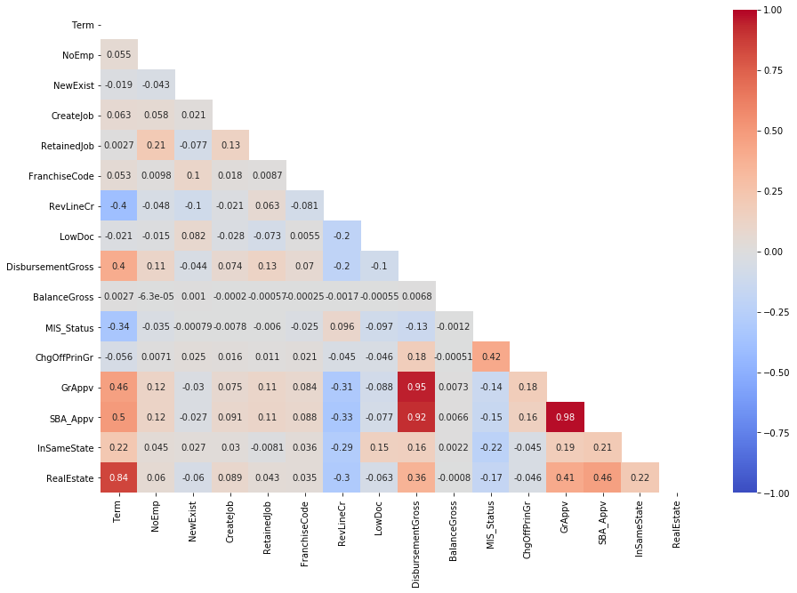

```python
corr_matrix = sba.corr()
corr_matrix

#code chunk is attributed as follows:
#Shaw, Chris (2019). How to customize seaborn correlation heat map. Medium.
#Retrieved from https://medium.com/@chrisshaw982/seaborn-correlation-heatmaps-customized-10246f4f7f4b.

import seaborn as sns

plt.figure(figsize=(15,10)) #need to adjust size as needed.
mask = np.zeros_like(corr_matrix, dtype=np.bool)
mask[np.triu_indices_from(mask)] = True

sns.heatmap(corr_matrix,
           vmin=-1,
           vmax=1,
           cmap='coolwarm',
           annot=True,
           mask=mask)
plt.show()
```

The GrAppv and SBA_Appv are highly positive related with DisbursementGross. The amount approved is close related with the amount disbursed. The amount SBA’s guaranteed amount of approved loan is closely related with the amount disbursed. Real Estate and Term are highly positively related.

```python
sba = sba.astype({'MIS_Status': 'category', 'NewExist': 'category', 'InSameState': 'category',
                  'LowDoc': 'category', 'RevLineCr': 'category', 'FranchiseCode': 'category',
                  'RealEstate': 'category'})
```

Change the category datas into categroy format. Check the data types with the code below.

```python
sba.dtypes
```

```
ApprovalFY             object
Term                    int64
NoEmp                   int64
NewExist             category
CreateJob               int64
RetainedJob             int64
FranchiseCode        category
UrbanRural             object
RevLineCr            category
LowDoc               category
DisbursementGross     float64
BalanceGross          float64
MIS_Status           category
ChgOffPrinGr          float64
GrAppv                float64
SBA_Appv              float64
Industry               object
InSameState          category
RealEstate           category
dtype: object
```

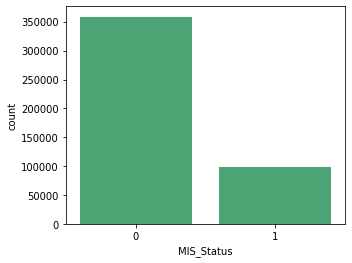

```python
f = plt.figure(figsize=(5,4))
sns.countplot(sba['MIS_Status'],color='MediumSeaGreen')
```

This graph shows the count of MIS_Status. The Paied in full is much more than Loan status charged off.

```
0    358558
1     98382
Name: MIS_Status, dtype: int64
```

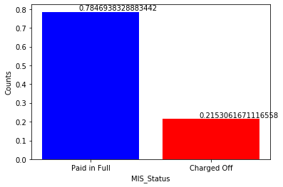

```python
# Bar chart for target value.
print(sba.MIS_Status.value_counts())

p = ((sba.MIS_Status == 1).sum()/(len(sba.MIS_Status)))
n = ((sba.MIS_Status == 0).sum()/(len(sba.MIS_Status)))

x = ['Paid in Full', 'Charged Off']
y = [n, p]

plt.bar(x, height = y, color = ['blue', 'red'])
xlocs, xlabs = plt.xticks()
xlocs = [i for i in range(0, 2)]
xlabs = x
plt.ylabel('Counts')
plt.xlabel('MIS_Status')

plt.xticks(xlocs, xlabs)
for i, v in enumerate(y):
    plt.text(xlocs[i]-0.1, v+0.008, str(v))
plt.show()
```

According to the graph above, about 78.47% of loans in the dataset were paid in full. About 21.53% of loans in the dataset were charged off.

```
0    358558
1     98382
Name: MIS_Status, dtype: int64
```

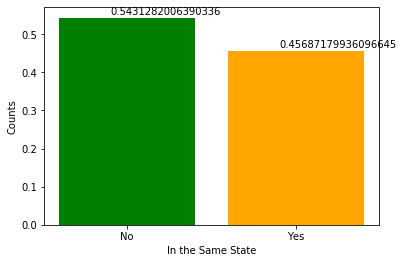

```python
# Bar chart for target value.
print(sba.MIS_Status.value_counts())

p = ((sba.InSameState == 1).sum()/(len(sba.InSameState)))
n = ((sba.InSameState == 0).sum()/(len(sba.InSameState)))

x = ['No', 'Yes']
y = [n, p]

plt.bar(x, height = y, color = ['green', 'orange'])
xlocs, xlabs = plt.xticks()
xlocs = [i for i in range(0, 2)]
xlabs = x
plt.ylabel('Counts')
plt.xlabel('In the Same State')

plt.xticks(xlocs, xlabs)
for i, v in enumerate(y):
    plt.text(xlocs[i]-0.1, v+0.008, str(v))
plt.show()
```

According to the graph above, about 46% small business loans were served by the banks in the same state with the small businesses.

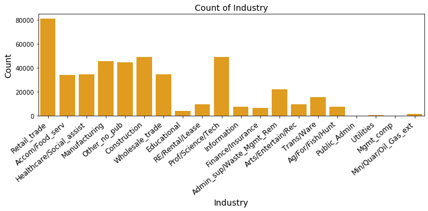

```python
f = plt.figure(figsize=(10,5))

ax = sns.countplot(sba['Industry'],color='orange',orient="h")
ax.set_xticklabels(ax.get_xticklabels(), rotation=40, ha="right",fontsize=12)

ax.set_title('Count of Industry', fontsize=14)
ax.set_xlabel('Industry',fontsize=14)
ax.set_ylabel('Count',fontsize=14)

plt.tight_layout()
plt.show()
```

In the industry, the Retail_trade have the highest count.

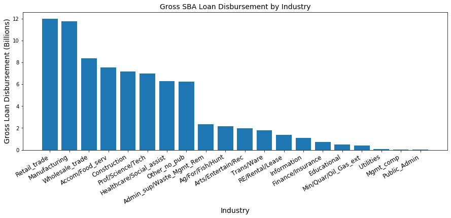

```python
indgroup = sba.groupby(['Industry'])

# Data frames based on groupby by Industry looking at aggregate and average values
df_industrySum = indgroup.sum().sort_values('DisbursementGross', ascending=False)

fig = plt.figure(figsize=(15, 5))

# Bar chart 1 = Gross SBA Loan Disbursement by Industry
ax = sns.countplot(df_industrySum.index,color='white')
ax.bar(df_industrySum.index, df_industrySum['DisbursementGross'] / 1000000000)
ax.set_xticklabels(df_industrySum.index, rotation=30, horizontalalignment='right', fontsize=12)

ax.set_title('Gross SBA Loan Disbursement by Industry', fontsize=14)
ax.set_xlabel('Industry',fontsize=14)
ax.set_ylabel('Gross Loan Disbursement (Billions)',fontsize=14)

plt.show()
```

According to the graph above, Retail_trade and Manufacturing obviously get more loan than the other industries.

#### Set MIS_Status as Target and move it to the first column

Move the target column to the first one. This makes it easy to dummy the data later, because it is easier to seperate the target column with other features.

```python
# designate target variable name
TargetName = 'MIS_Status'
#print(TargetName)
TargetSeries = sba[TargetName] #notice one column is considered a series in pandas
#print(TargetSeries)
#remove target from current location and insert in column number 0
del sba[TargetName]
sba.insert(0, TargetName, TargetSeries)
#reprint dataframe and see target is in position 0
sba.head()
```

|  | MIS_Status | ApprovalFY | Term | NoEmp | NewExist | CreateJob | RetainedJob | FranchiseCode | UrbanRural | RevLineCr | LowDoc | DisbursementGross | BalanceGross | ChgOffPrinGr | GrAppv | SBA_Appv | Industry | InSameState | RealEstate |
| --- | --- | --- | --- | --- | --- | --- | --- | --- | --- | --- | --- | --- | --- | --- | --- | --- | --- | --- | --- |
| 0 | 0 | 1997 | 84 | 4 | 1 | 0 | 0 | 0 | 0 | 0 | 1 | 60000.0 | 0.0 | 0.0 | 60000.0 | 48000.0 | Retail_trade | 0 | 0 |
| 1 | 0 | 1997 | 60 | 2 | 1 | 0 | 0 | 0 | 0 | 0 | 1 | 40000.0 | 0.0 | 0.0 | 40000.0 | 32000.0 | Accom/Food_serv | 1 | 0 |
| 2 | 0 | 1997 | 180 | 7 | 0 | 0 | 0 | 0 | 0 | 0 | 0 | 287000.0 | 0.0 | 0.0 | 287000.0 | 215250.0 | Healthcare/Social_assist | 1 | 0 |
| 5 | 0 | 1997 | 120 | 19 | 0 | 0 | 0 | 0 | 0 | 0 | 0 | 517000.0 | 0.0 | 0.0 | 517000.0 | 387750.0 | Manufacturing | 0 | 0 |
| 7 | 0 | 1997 | 84 | 1 | 1 | 0 | 0 | 0 | 0 | 0 | 1 | 45000.0 | 0.0 | 0.0 | 45000.0 | 36000.0 | Other_no_pub | 0 | 0 |

#### Put Industry as the second column

Make it easier to find the industry column when checking the data.

```python
TargetName = 'Industry'
TargetSeries = sba[TargetName]

del sba[TargetName]
sba.insert(1, TargetName, TargetSeries)

sba.head()
```

|  | MIS_Status | Industry | ApprovalFY | Term | NoEmp | NewExist | CreateJob | RetainedJob | FranchiseCode | UrbanRural | RevLineCr | LowDoc | DisbursementGross | BalanceGross | ChgOffPrinGr | GrAppv | SBA_Appv | InSameState | RealEstate |
| --- | --- | --- | --- | --- | --- | --- | --- | --- | --- | --- | --- | --- | --- | --- | --- | --- | --- | --- | --- |
| 0 | 0 | Retail_trade | 1997 | 84 | 4 | 1 | 0 | 0 | 0 | 0 | 0 | 1 | 60000.0 | 0.0 | 0.0 | 60000.0 | 48000.0 | 0 | 0 |
| 1 | 0 | Accom/Food_serv | 1997 | 60 | 2 | 1 | 0 | 0 | 0 | 0 | 0 | 1 | 40000.0 | 0.0 | 0.0 | 40000.0 | 32000.0 | 1 | 0 |
| 2 | 0 | Healthcare/Social_assist | 1997 | 180 | 7 | 0 | 0 | 0 | 0 | 0 | 0 | 0 | 287000.0 | 0.0 | 0.0 | 287000.0 | 215250.0 | 1 | 0 |
| 5 | 0 | Manufacturing | 1997 | 120 | 19 | 0 | 0 | 0 | 0 | 0 | 0 | 0 | 517000.0 | 0.0 | 0.0 | 517000.0 | 387750.0 | 0 | 0 |
| 7 | 0 | Other_no_pub | 1997 | 84 | 1 | 1 | 0 | 0 | 0 | 0 | 0 | 1 | 45000.0 | 0.0 | 0.0 | 45000.0 | 36000.0 | 0 | 0 |

### Convert the categorical variables into dummies.

```python
SBA = sba
```

```python
# This code turns a character/text target variable into numeric one
from sklearn import preprocessing
le_dep = preprocessing.LabelEncoder()
#to convert into numbers
SBA['MIS_Status'] = le_dep.fit_transform(SBA['MIS_Status'])
```

```python
# perform data transformation. Creates dummy variables for categorical variables.
for col in SBA.columns[1:]:
	attName = col
	dType = SBA[col].dtype
	missing = pd.isnull(SBA[col]).any()
	uniqueCount = len(SBA[attName].value_counts(normalize=False))
	# discretize (create dummies)
	if dType == object:
		SBA = pd.concat([SBA, pd.get_dummies(SBA[col], prefix=col)], axis=1)
		del SBA[attName]
```

```python
print(SBA.shape)
```

```
(456940, 72)
```

```python
print(SBA.columns)
```

```
Index(['MIS_Status', 'Term', 'NoEmp', 'NewExist', 'CreateJob', 'RetainedJob',
       'FranchiseCode', 'RevLineCr', 'LowDoc', 'DisbursementGross',
       'BalanceGross', 'ChgOffPrinGr', 'GrAppv', 'SBA_Appv', 'InSameState',
       'RealEstate', 'Industry_Accom/Food_serv',
       'Industry_Admin_sup/Waste_Mgmt_Rem', 'Industry_Ag/For/Fish/Hunt',
       'Industry_Arts/Entertain/Rec', 'Industry_Construction',
       'Industry_Educational', 'Industry_Finance/Insurance',
       'Industry_Healthcare/Social_assist', 'Industry_Information',
       'Industry_Manufacturing', 'Industry_Mgmt_comp',
       'Industry_Min/Quar/Oil_Gas_ext', 'Industry_Other_no_pub',
       'Industry_Prof/Science/Tech', 'Industry_Public_Admin',
       'Industry_RE/Rental/Lease', 'Industry_Retail_trade',
       'Industry_Trans/Ware', 'Industry_Utilities', 'Industry_Wholesale_trade',
       'ApprovalFY_1984', 'ApprovalFY_1987', 'ApprovalFY_1988',
       'ApprovalFY_1989', 'ApprovalFY_1990', 'ApprovalFY_1991',
       'ApprovalFY_1992', 'ApprovalFY_1993', 'ApprovalFY_1994',
       'ApprovalFY_1996', 'ApprovalFY_1997', 'ApprovalFY_1998',
       'ApprovalFY_1999', 'ApprovalFY_2000', 'ApprovalFY_2001',
       'ApprovalFY_2002', 'ApprovalFY_2003', 'ApprovalFY_2004',
       'ApprovalFY_2005', 'ApprovalFY_2006', 'ApprovalFY_2007',
       'ApprovalFY_2008', 'ApprovalFY_2009', 'ApprovalFY_2010',
       'ApprovalFY_2011', 'ApprovalFY_2012', 'ApprovalFY_2013',
       'ApprovalFY_2014', 'ApprovalFY_1994', 'ApprovalFY_1995',
       'ApprovalFY_1996', 'ApprovalFY_2004', 'ApprovalFY_2005', 'UrbanRural_0',
       'UrbanRural_1', 'UrbanRural_2'],
      dtype='object')
```

Check the null values again.

```python
SBA.isna().sum()
```

[output not shown]

There is no null value exists.

# Models

After Data Exploration Analysis, we get to know the data better. I will use several models to predict the MIS_Status, in which 0 = Paid in full (PIF) and 1 = Loan status charged off (CHGOFF).

#### Create a training and test (or validation) set. Use any split: 80/20

```python
# Establish target and feature fields
from sklearn.model_selection import train_test_split
from sklearn.preprocessing import StandardScaler

x = SBA.iloc[:,1:]
y = SBA.iloc[:,0].values

# Scale the feature values prior to modeling
scale = StandardScaler()
x_s = scale.fit_transform(x)

x_train, x_test, y_train, y_test = train_test_split(x_s, y, test_size=0.20, random_state=0)

print(x_train.shape)
print(x_test.shape)
print(y_train.shape)
print(y_test.shape)
```

```
(365552, 71)
(91388, 71)
(365552,)
(91388,)
```

Set functions for creating feature importance dataframe and horizontal barchart with code below.

```python
# Code borrowed from https://github.com/erykml/medium_articles/blob/master/Machine%20Learning/feature_importance.ipynb
# function for creating a feature importance dataframe
def imp_df(column_names, importances):
    df = pd.DataFrame({'feature': column_names,
                       'feature_importance': importances}) \
           .sort_values('feature_importance', ascending = False) \
           .reset_index(drop = True)
    return df

# plotting a feature importance dataframe (horizontal barchart)
def var_imp_plot(imp_df, title):
    imp_df.columns = ['feature', 'feature_importance']
    sns.barplot(x = 'feature_importance', y = 'feature', data = imp_df, orient = 'h', color = 'royalblue') \
       .set_title(title, fontsize = 20)
```

### KNN

- Perform a KNN=3 classifier.

```python
# KNN
from sklearn import metrics
from sklearn.neighbors import KNeighborsClassifier

# instantiate learning model (k = 3)
KNN = KNeighborsClassifier(n_neighbors=3)
print(KNN)

# Train the model
KNN.fit(x_train, y_train)


# make predictions
clf2_expected = y_test
clf2_predicted = KNN.predict(x_test)


#print(KNN.score(x_test,y_test))
KNN_accuracy =  round((accuracy_score(clf2_expected, clf2_predicted)*100), 2)

# summarize the fit of the model
print('Classification Report: ')
print("Accuracy : " , KNN_accuracy , " %")
print(metrics.classification_report(clf2_expected, clf2_predicted))

# Confusion Matrix
print('Confusion Matrix: ')
print(confusion_matrix(clf2_expected, clf2_predicted))

#extracting true_positives, false_positives, true_negatives, false_negatives
tn, fp, fn, tp = confusion_matrix(clf2_expected, clf2_predicted).ravel()
print("True Negatives: ",tn)
print("False Positives: ",fp)
print("False Negatives: ",fn)
print("True Positives: ",tp)
```

```
KNeighborsClassifier(algorithm='auto', leaf_size=30, metric='minkowski',
                     metric_params=None, n_jobs=None, n_neighbors=3, p=2,
                     weights='uniform')
Classification Report:
Accuracy :  96.08  %
              precision    recall  f1-score   support

           0       0.97      0.98      0.98     71742
           1       0.94      0.88      0.91     19646

    accuracy                           0.96     91388
   macro avg       0.95      0.93      0.94     91388
weighted avg       0.96      0.96      0.96     91388

Confusion Matrix:
[[70590  1152]
 [ 2430 17216]]
True Negatives:  70590
False Positives:  1152
False Negatives:  2430
True Positives:  17216
```

The accuracy rate of KNN is 96.08%. The recall rate of Charged off is 0.88.

#### Cross Validate KNN

```python
#verify KNN with 10-fold cross validation
scores = cross_val_score(KNN, x_train, y_train, cv=10)
print("Cross Validation Score for each K",scores)
KNN_cv = round((scores.mean()*100),2)
print('Average Accuracy Rate: ', round((scores.mean()*100),1),'%')
```

```
Cross Validation Score for each K [0.96008863 0.96047161 0.95984133 0.96101764 0.9606073  0.95896594
 0.95970455 0.96085351 0.9589933  0.9606073 ]
Average Accuracy Rate:  96.0 %
```

To prevent overfitting, I applied cross validation to the KNN model. After cross validation, the average accuracy rate is 96.0%. This means the accuracy rate of 96.08% is not overfitting.

## Decision Tree

```python
from sklearn import metrics
from sklearn.tree import DecisionTreeClassifier
from sklearn.metrics import accuracy_score

# fit a Decision Tree model to the data
DT = DecisionTreeClassifier(random_state = 123)
print(DT)

# Train the Model
DT.fit(x_train, y_train)

# make predictions
clf1_expected = y_test
clf1_predicted = DT.predict(x_test)

DT_accuracy =  round((accuracy_score(clf1_expected, clf1_predicted)*100), 2)

# summarize the fit of the model
print('Classification Report: ')
print("Accuracy : " , DT_accuracy , " %")
print(metrics.classification_report(clf1_expected, clf1_predicted))

# Confusion Matrix
print('Confusion Matrix: ')
print(confusion_matrix(clf1_expected, clf1_predicted))

#extracting true_positives, false_positives, true_negatives, false_negatives
tn, fp, fn, tp = confusion_matrix(clf1_expected, clf1_predicted).ravel()
print("True Negatives: ",tn)
print("False Positives: ",fp)
print("False Negatives: ",fn)
print("True Positives: ",tp)
```

```
DecisionTreeClassifier(ccp_alpha=0.0, class_weight=None, criterion='gini',
                       max_depth=None, max_features=None, max_leaf_nodes=None,
                       min_impurity_decrease=0.0, min_impurity_split=None,
                       min_samples_leaf=1, min_samples_split=2,
                       min_weight_fraction_leaf=0.0, presort='deprecated',
                       random_state=123, splitter='best')
Classification Report:
Accuracy :  98.75  %
              precision    recall  f1-score   support

           0       0.99      0.99      0.99     71742
           1       0.97      0.97      0.97     19646

    accuracy                           0.99     91388
   macro avg       0.98      0.98      0.98     91388
weighted avg       0.99      0.99      0.99     91388

Confusion Matrix:
[[71212   530]
 [  614 19032]]
True Negatives:  71212
False Positives:  530
False Negatives:  614
True Positives:  19032
```

The accuracy of decision tree is 98.75%. The recall of charged off 0.97.

```python
print('Training Score: {:.2f} \nTest Score: {:.2f}'.format(DT.score(x_train, y_train),
                                                                 DT.score(x_test, y_test)))
```

```
Training Score: 1.00
Test Score: 0.99
```

The training score is 1.00. The test score is 0.99. The training score and test score are very close, which means the high accuracy rate of Decision Tree is not overfitting.

```python
base_imp = imp_df(x.columns, DT.feature_importances_).head(10)
base_imp
```

[output not shown]

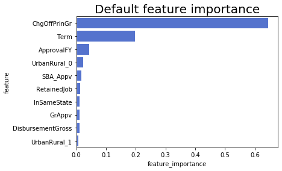

```python
var_imp_plot(base_imp,'Default feature importance')
```

According to the graph above, the ChgOffPrinGr, Term, and ApprovalFY are the tope 3 most important features.

Cross validate Decision Tree using CV= 10.

```python
scores = cross_val_score(DT, x_train, y_train, cv=10)
print("Cross Validation Score for each K",scores)
DT_cv = round((scores.mean()*100),2)
print('Average Accuracy Rate: ', round((scores.mean()*100),1),'%')
```

```
Cross Validation Score for each K [0.98722508 0.98624029 0.98717002 0.98651347 0.98695117 0.98673232
 0.98648612 0.98703324 0.98596635 0.98774449]
Average Accuracy Rate:  98.7 %
```

To prevent overfitting, I applied cross validation to the decision tree model. After cross validation, the average accuracy rate is 98.7%. This means the accuracy rate of 98.75% is not overfitting.

## Random Forest

```python
from sklearn.ensemble import RandomForestClassifier
#Build
clf_rf = RandomForestClassifier(class_weight='balanced', max_features='auto', n_estimators=100, random_state=123)
#max_features = 'auto' for default. Calculated as square root of number of features.
print(clf_rf)
#Train
clf_rf.fit(x_train, y_train)
#Validate
target_predicted = clf_rf.predict(x_test)
print("Random Forfest Accuracy", accuracy_score(y_test, target_predicted))
target_names = ['0', '1']
print(classification_report(y_test, target_predicted, target_names=target_names))

# Confusion Matrix
print('Confusion Matrix: ')
print(confusion_matrix(y_test, target_predicted))

#extracting true_positives, false_positives, true_negatives, false_negatives
tn, fp, fn, tp = confusion_matrix(y_test, target_predicted).ravel()
print("True Negatives: ",tn)
print("False Positives: ",fp)
print("False Negatives: ",fn)
print("True Positives: ",tp)
```

```
RandomForestClassifier(bootstrap=True, ccp_alpha=0.0, class_weight='balanced',
                       criterion='gini', max_depth=None, max_features='auto',
                       max_leaf_nodes=None, max_samples=None,
                       min_impurity_decrease=0.0, min_impurity_split=None,
                       min_samples_leaf=1, min_samples_split=2,
                       min_weight_fraction_leaf=0.0, n_estimators=100,
                       n_jobs=None, oob_score=False, random_state=123,
                       verbose=0, warm_start=False)
Random Forfest Accuracy 0.9938503961132753
              precision    recall  f1-score   support

           0       1.00      0.99      1.00     71742
           1       0.97      1.00      0.99     19646

    accuracy                           0.99     91388
   macro avg       0.99      1.00      0.99     91388
weighted avg       0.99      0.99      0.99     91388

Confusion Matrix:
[[71202   540]
 [   22 19624]]
True Negatives:  71202
False Positives:  540
False Negatives:  22
True Positives:  19624
```

```python
print('Training Score: {:.2f} \nTest Score: {:.2f}'.format(clf_rf.score(x_train, y_train),
                                                                 clf_rf.score(x_test, y_test)))
```

```
Training Score: 1.00
Test Score: 0.99
```

The training score is 1.00. The test score is 0.99. The training score and test score are very close, which means the high accuracy rate of Random Forest is not overfitting.

```python
base_imp = imp_df(x.columns, clf_rf.feature_importances_).head(10)
base_imp
```

|  | feature | feature_importance |
| --- | --- | --- |
| 0 | ChgOffPrinGr | 0.621666 |
| 1 | Term | 0.200495 |
| 2 | UrbanRural_0 | 0.025272 |
| 3 | SBA_Appv | 0.023329 |
| 4 | DisbursementGross | 0.014119 |
| 5 | GrAppv | 0.013191 |
| 6 | InSameState | 0.012064 |
| 7 | ApprovalFY_2007 | 0.012038 |
| 8 | RetainedJob | 0.010827 |
| 9 | RealEstate | 0.008232 |

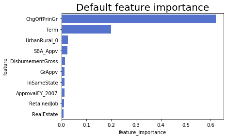

```python
var_imp_plot(base_imp,'Default feature importance')
```

According to the graph above, the ChgOffPrinGr, Term, and UrbanRural_0 are the tope 3 most important features. UrbanRural_0 is undefinded urbanrural.

Verify Random Forest with 10-fold cross validation

```python
scores = cross_val_score(clf_rf, x_train, y_train, cv=10)
print("Cross Validation Score for each K",scores)
clf_rf_cv = round((scores.mean()*100),2)
print('Average Accuracy Rate: ', round((scores.mean()*100),1),'%')
```

```
Cross Validation Score for each K [0.99387241 0.99321589 0.99392696 0.99264123 0.99258651 0.99368076
 0.99351662 0.99368076 0.99373547 0.99376282]
Average Accuracy Rate:  99.3 %
```

To prevent overfitting, I applied cross validation to the Random Forest model. After cross validation, the average accuracy rate is 99.3%. This means the accuracy rate of 99.39% is not overfitting.

## ANN - Multilayer Perceptron Model (MLP)

```python
from sklearn.preprocessing import StandardScaler
#Build
scaler = StandardScaler()
#Train
scaler.fit(x_train)
#Validate
features_train_norm = scaler.transform(x_train)
# apply same transformation to test data
features_test_norm = scaler.transform(x_test)
```

```python
#Build
from sklearn.neural_network import MLPClassifier
#clf_nn = MLPClassifier(hidden_layer_sizes=(5),random_state=0) #one hidden layer with five units/nodes
#clf_nn = MLPClassifier(hidden_layer_sizes=(5), solver="lbfgs",random_state=0) #one hidden layer with five units/nodes
#clf_nn = MLPClassifier(hidden_layer_sizes=(5), solver="sgd", learning_rate="adaptive", max_iter=1000,random_state=0)
#clf_nn = MLPClassifier(hidden_layer_sizes=(5,5), solver="sgd", learning_rate="adaptive", max_iter=1000,random_state=0)
clf_nn = MLPClassifier(hidden_layer_sizes=(20,20), solver="sgd", learning_rate="adaptive", max_iter=10000,random_state=0)
#Train
clf_nn.fit(features_train_norm, y_train)
#Validate
target_predicted = clf_nn.predict(features_test_norm)
print("Accuracy", accuracy_score(y_test, target_predicted))
target_names = ['0', '1']
print(classification_report(y_test, target_predicted, target_names=target_names))

# Confusion Matrix
print('Confusion Matrix: ')
print(confusion_matrix(y_test, target_predicted))

#extracting true_positives, false_positives, true_negatives, false_negatives
tn, fp, fn, tp = confusion_matrix(y_test, target_predicted).ravel()
print("True Negatives: ",tn)
print("False Positives: ",fp)
print("False Negatives: ",fn)
print("True Positives: ",tp)
```

```
Accuracy 0.9890904713966823
              precision    recall  f1-score   support

           0       0.99      0.99      0.99     71742
           1       0.98      0.97      0.97     19646

    accuracy                           0.99     91388
   macro avg       0.98      0.98      0.98     91388
weighted avg       0.99      0.99      0.99     91388

Confusion Matrix:
[[71255   487]
 [  510 19136]]
True Negatives:  71255
False Positives:  487
False Negatives:  510
True Positives:  19136
```

```python
print('Training Score: {:.2f} \nTest Score: {:.2f}'.format(clf_nn.score(x_train, y_train),
                                                                 clf_nn.score(x_test, y_test)))
```

```
Training Score: 0.99
Test Score: 0.99
```

The training score is 0.99. The test score is 0.99. The training score and test score are very close, which means the high accuracy rate of Multilayer Percepton Model is not overfitting.

Verify Multilayer Perceptron Model with 10-fold cross validation

```python
scores = cross_val_score(clf_nn, x_train, y_train, cv=10)
print("Cross Validation Score for each K",scores)
clf_nn_cv = round((scores.mean()*100),2)
print('Average Accuracy Rate: ', round((scores.mean()*100),1),'%')
```

```
Cross Validation Score for each K [0.98848342 0.98730715 0.98766243 0.98774449 0.98788127 0.98944057
 0.98840104 0.98859253 0.98861989 0.98897552]
Average Accuracy Rate:  98.8 %
```

To prevent overfitting, I applied cross validation to the Multilayer Perceptron Model. After cross validation, the average accuracy rate is 98.8%. This means the accuracy rate of 98.9% is not overfitting.

## Stochastic Gradient Descent

```python
#Build
from sklearn.linear_model import SGDClassifier
clf_sgd_linear_svm = SGDClassifier(random_state=0)
#Train
clf_sgd_linear_svm.fit(features_train_norm, y_train)
#Validate
target_predicted = clf_sgd_linear_svm.predict(features_test_norm)
print("Accuracy", accuracy_score(y_test, target_predicted))
target_names = ['0','1']
print(classification_report(y_test, target_predicted, target_names=target_names))

# Confusion Matrix
print('Confusion Matrix: ')
print(confusion_matrix(y_test, target_predicted))

#extracting true_positives, false_positives, true_negatives, false_negatives
tn, fp, fn, tp = confusion_matrix(y_test, target_predicted).ravel()
print("True Negatives: ",tn)
print("False Positives: ",fp)
print("False Negatives: ",fn)
print("True Positives: ",tp)
```

```
Accuracy 0.9876679651595396
              precision    recall  f1-score   support

           0       0.99      0.99      0.99     71742
           1       0.98      0.97      0.97     19646

    accuracy                           0.99     91388
   macro avg       0.98      0.98      0.98     91388
weighted avg       0.99      0.99      0.99     91388

Confusion Matrix:
[[71293   449]
 [  678 18968]]
True Negatives:  71293
False Positives:  449
False Negatives:  678
True Positives:  18968
```

```python
print('Training Score: {:.2f} \nTest Score: {:.2f}'.format(clf_sgd_linear_svm.score(x_train, y_train),
                                                                 clf_sgd_linear_svm.score(x_test, y_test)))
```

```
Training Score: 0.99
Test Score: 0.99
```

The training score is 0.99. The test score is 0.99. The training score and test score are very close, which means the high accuracy rate of Stochastic Gradient Descent is not overfitting.

Verify Stochastic Gradient Descent with 10-fold cross validation

```python
scores = cross_val_score(clf_sgd_linear_svm, x_train, y_train, cv=10)
print("Cross Validation Score for each K",scores)
clf_sgd_linear_svm_cv = round((scores.mean()*100),2)
print('Average Accuracy Rate: ', round((scores.mean()*100),1),'%')
```

```
Cross Validation Score for each K [0.98659591 0.98613087 0.98733415 0.98741622 0.9857475  0.98801805
 0.98684175 0.98851046 0.98870196 0.98725209]
Average Accuracy Rate:  98.7 %
```

To prevent overfitting, I applied cross validation to the Stochastic Gradient Descent model. After cross validation, the average accuracy rate is 98.7%. This means the accuracy rate of 98.77% is not overfitting.

## Adaboost

```python
#https://scikit-learn.org/stable/modules/generated/sklearn.ensemble.AdaBoostClassifier.html
from sklearn.ensemble import AdaBoostClassifier
from sklearn import tree
clf_dt_ab = AdaBoostClassifier(tree.DecisionTreeClassifier(class_weight="balanced"),
                         algorithm="SAMME.R",
                         n_estimators=100, random_state=123)
clf_dt_ab.fit(x_train, y_train)
target_predicted=clf_dt_ab.predict(x_test)
print("Adaboost Accuracy", accuracy_score(y_test,target_predicted))
target_names = ['0','1']
print(classification_report(y_test, target_predicted,target_names=target_names))

# Confusion Matrix
print('Confusion Matrix: ')
print(confusion_matrix(y_test, target_predicted))

#extracting true_positives, false_positives, true_negatives, false_negatives
tn, fp, fn, tp = confusion_matrix(y_test, target_predicted).ravel()
print("True Negatives: ",tn)
print("False Positives: ",fp)
print("False Negatives: ",fn)
print("True Positives: ",tp)
```

```
Adaboost Accuracy 0.9869129426182869
              precision    recall  f1-score   support

           0       0.99      0.99      0.99     71742
           1       0.97      0.97      0.97     19646

    accuracy                           0.99     91388
   macro avg       0.98      0.98      0.98     91388
weighted avg       0.99      0.99      0.99     91388

Confusion Matrix:
[[71228   514]
 [  682 18964]]
True Negatives:  71228
False Positives:  514
False Negatives:  682
True Positives:  18964
```

The accuracy of Adaboost is 98.69%. The recall rate of Charged off is 0.97.

```python
print('Training Score: {:.2f} \nTest Score: {:.2f}'.format(clf_dt_ab.score(x_train, y_train),
                                                                 clf_dt_ab.score(x_test, y_test)))
```

```
Training Score: 1.00
Test Score: 0.99
```

The training score is 1.00. The test score is 0.99. The training score and test score are very close, which means the high accuracy rate of Adaboost is not overfitting.

```python
base_imp = imp_df(x.columns, clf_dt_ab.feature_importances_).head(10)
base_imp
```

|  | feature | feature_importance |
| --- | --- | --- |
| 0 | ChgOffPrinGr | 0.985389 |
| 1 | Term | 0.002642 |
| 2 | DisbursementGross | 0.002055 |
| 3 | NoEmp | 0.001164 |
| 4 | SBA_Appv | 0.001106 |
| 5 | CreateJob | 0.001013 |
| 6 | RetainedJob | 0.000858 |
| 7 | GrAppv | 0.000590 |
| 8 | InSameState | 0.000382 |
| 9 | Industry_Retail_trade | 0.000335 |

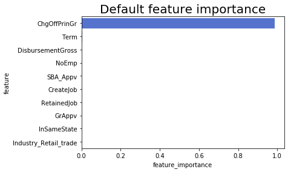

```python
var_imp_plot(base_imp,'Default feature importance')
```

Verify Adaboost with 10-fold cross validation

```python
scores = cross_val_score(clf_dt_ab, x_train, y_train, cv=10)
print("Cross Validation Score for each K",scores)
clf_dt_ab_cv = round((scores.mean()*100),2)
print('Average Accuracy Rate: ', round((scores.mean()*100),1),'%')
```

```
Cross Validation Score for each K [0.98755334 0.98665062 0.9868691  0.9857475  0.9850636  0.9864314
 0.98651347 0.98670497 0.98648612 0.98818219]
Average Accuracy Rate:  98.7 %
```

To prevent overfitting, I applied cross validation to the Adaboost model. After cross validation, the average accuracy rate is 98.7%. This means the accuracy rate of 98.69% is not overfitting.

## Bagging Classifier

```python
from sklearn.ensemble import BaggingClassifier
#Build
clf_bag = BaggingClassifier(n_estimators=100, random_state=123)
print(clf_bag)
#Train
clf_bag.fit(x_train, y_train)
#Validate
target_predicted=clf_bag.predict(x_test)
print("Bagging Accuracy", accuracy_score(y_test, target_predicted))
target_names = ["0", "1"]
print(classification_report(y_test, target_predicted,target_names=target_names))

# Confusion Matrix
print('Confusion Matrix: ')
print(confusion_matrix(y_test, target_predicted))

#extracting true_positives, false_positives, true_negatives, false_negatives
tn, fp, fn, tp = confusion_matrix(y_test, target_predicted).ravel()
print("True Negatives: ",tn)
print("False Positives: ",fp)
print("False Negatives: ",fn)
print("True Positives: ",tp)
```

```
BaggingClassifier(base_estimator=None, bootstrap=True, bootstrap_features=False,
                  max_features=1.0, max_samples=1.0, n_estimators=100,
                  n_jobs=None, oob_score=False, random_state=123, verbose=0,
                  warm_start=False)
Bagging Accuracy 0.9938722808246159
              precision    recall  f1-score   support

           0       1.00      0.99      1.00     71742
           1       0.97      1.00      0.99     19646

    accuracy                           0.99     91388
   macro avg       0.99      1.00      0.99     91388
weighted avg       0.99      0.99      0.99     91388

Confusion Matrix:
[[71202   540]
 [   20 19626]]
True Negatives:  71202
False Positives:  540
False Negatives:  20
True Positives:  19626
```

The accuracy rate of Bagging Classifier is 99.39%. The recall rate of Charged off is 1.00.

```python
print('Training Score: {:.2f} \nValidation Score: {:.2f}'.format(clf_bag.score(x_train, y_train),
                                                                 clf_bag.score(x_test, y_test)))
```

```
Training Score: 1.00
Validation Score: 0.99
```

The training score is 1.00. The test score is 0.99. The training score and test score are very close, which means the high accuracy rate of Bagging Classifier is not overfitting.

Verify Bagging Classifier with 10-fold cross validation

```python
scores = cross_val_score(clf_bag, x_train, y_train, cv=10)
print("Cross Validation Score for each K",scores)
clf_bag_cv = round((scores.mean()*100),2)
print('Average Accuracy Rate: ', round((scores.mean()*100),1),'%')
```

```
Cross Validation Score for each K [0.9938177  0.99324324 0.99400903 0.99266858 0.99258651 0.99359869
 0.99346191 0.9938996  0.99357133 0.99379018]
Average Accuracy Rate:  99.3 %
```

To prevent overfitting, I applied cross validation to the Bagging Classifier model. After cross validation, the average accuracy rate is 99.3%. This means the accuracy rate of 99.39% is not overfitting.

## Gradient Boosting

```python
from sklearn.ensemble import GradientBoostingClassifier
clf_GBC = GradientBoostingClassifier(n_estimators = 60,learning_rate=0.2, min_samples_split=800,min_samples_leaf=50,
                                     max_depth=5,max_features='sqrt',subsample=0.8,random_state=123)
clf_GBC.fit(x_train, y_train)
target_predicted=clf_GBC.predict(x_test)
print("Gradient Boost Accuracy", accuracy_score(y_test,target_predicted))
target_names = ["0", "1"]
print(classification_report(target_predicted, y_test, target_names=target_names))

# Confusion Matrix
print('Confusion Matrix: ')
print(confusion_matrix(y_test, target_predicted))

#extracting true_positives, false_positives, true_negatives, false_negatives
tn, fp, fn, tp = confusion_matrix(y_test, target_predicted).ravel()
print("True Negatives: ",tn)
print("False Positives: ",fp)
print("False Negatives: ",fn)
print("True Positives: ",tp)
```

```
Gradient Boost Accuracy 0.9938503961132753
              precision    recall  f1-score   support

           0       0.99      1.00      1.00     71224
           1       1.00      0.97      0.99     20164

    accuracy                           0.99     91388
   macro avg       1.00      0.99      0.99     91388
weighted avg       0.99      0.99      0.99     91388

Confusion Matrix:
[[71202   540]
 [   22 19624]]
True Negatives:  71202
False Positives:  540
False Negatives:  22
True Positives:  19624
```

The accuracy rate of Gradient Boosting is 99.39%. The recall rate of Charged off is 0.97.

```python
print('Training Score: {:.2f} \nValidation Score: {:.2f}'.format(clf_GBC.score(x_train, y_train),
                                                                 clf_GBC.score(x_test, y_test)))
```

```
Training Score: 0.99
Validation Score: 0.99
```

The training score is 0.99. The test score is 0.99. The training score and test score are very close, which means the high accuracy rate of Gradient Boosting is not overfitting.

```python
base_imp = imp_df(x.columns, clf_GBC.feature_importances_).head(10)
base_imp
```

|  | feature | feature_importance |
| --- | --- | --- |
| 0 | ChgOffPrinGr | 0.671828 |
| 1 | Term | 0.248547 |
| 2 | ApprovalFY_2007 | 0.012771 |
| 3 | InSameState | 0.012530 |
| 4 | GrAppv | 0.010684 |
| 5 | RealEstate | 0.008276 |
| 6 | UrbanRural_0 | 0.006637 |
| 7 | SBA_Appv | 0.004432 |
| 8 | ApprovalFY_2008 | 0.003848 |
| 9 | DisbursementGross | 0.003205 |

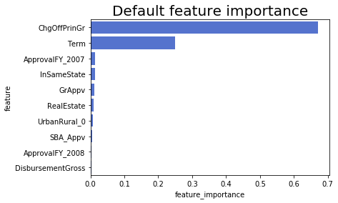

```python
var_imp_plot(base_imp,'Default feature importance')
```

According to the graph above, the ChgOffPrinGr, Term, and ApprovalFY are the tope 3 most important features.

Verify Gradient Boosting with 10-fold cross validation

```python
scores = cross_val_score(clf_GBC, x_train, y_train, cv=10)
print("Cross Validation Score for each K",scores)
clf_GBC_cv = round((scores.mean()*100),2)
print('Average Accuracy Rate: ', round((scores.mean()*100),1),'%')
```

```
Cross Validation Score for each K [0.99395448 0.99321589 0.99403638 0.99277801 0.99269594 0.99373547
 0.99354397 0.99373547 0.99376282 0.99373547]
Average Accuracy Rate:  99.4 %
```

To prevent overfitting, I applied cross validation to the Gradient Boosting model. After cross validation, the average accuracy rate is 99.4%. This means the accuracy rate of 99.39% is not overfitting.

## Extra Trees

```python
from sklearn.ensemble import ExtraTreesClassifier
clf_xdt = ExtraTreesClassifier(random_state=123)
print(clf_xdt)
clf_xdt.fit(x_train, y_train)
target_predicted=clf_xdt.predict(x_test)
print("Extra Trees Accuracy", accuracy_score(y_test,target_predicted))
target_names = ["0", "1"]
print(classification_report(y_test, target_predicted,target_names=target_names))

# Confusion Matrix
print('Confusion Matrix: ')
print(confusion_matrix(y_test, target_predicted))

#extracting true_positives, false_positives, true_negatives, false_negatives
tn, fp, fn, tp = confusion_matrix(y_test, target_predicted).ravel()
print("True Negatives: ",tn)
print("False Positives: ",fp)
print("False Negatives: ",fn)
print("True Positives: ",tp)
```

```
ExtraTreesClassifier(bootstrap=False, ccp_alpha=0.0, class_weight=None,
                     criterion='gini', max_depth=None, max_features='auto',
                     max_leaf_nodes=None, max_samples=None,
                     min_impurity_decrease=0.0, min_impurity_split=None,
                     min_samples_leaf=1, min_samples_split=2,
                     min_weight_fraction_leaf=0.0, n_estimators=100,
                     n_jobs=None, oob_score=False, random_state=123, verbose=0,
                     warm_start=False)
Extra Trees Accuracy 0.9882697947214076
              precision    recall  f1-score   support

           0       0.99      0.99      0.99     71742
           1       0.97      0.97      0.97     19646

    accuracy                           0.99     91388
   macro avg       0.98      0.98      0.98     91388
weighted avg       0.99      0.99      0.99     91388

Confusion Matrix:
[[71191   551]
 [  521 19125]]
True Negatives:  71191
False Positives:  551
False Negatives:  521
True Positives:  19125
```

```python
print('Training Score: {:.2f} \nTest Score: {:.2f}'.format(clf_xdt.score(x_train, y_train),
                                                                 clf_xdt.score(x_test, y_test)))
```

```
Training Score: 1.00
Test Score: 0.99
```

The training score is 1.00. The test score is 0.99. The training score and test score are very close, which means the high accuracy rate of Extra Trees is not overfitting.

```python
base_imp = imp_df(x.columns, clf_xdt.feature_importances_).head(10)
base_imp
```

|  | feature | feature_importance |
| --- | --- | --- |
| 0 | ChgOffPrinGr | 0.449999 |
| 1 | Term | 0.209294 |
| 2 | ApprovalFY_2007 | 0.031873 |
| 3 | GrAppv | 0.028780 |
| 4 | DisbursementGross | 0.027855 |
| 5 | SBA_Appv | 0.027145 |
| 6 | InSameState | 0.025774 |
| 7 | UrbanRural_0 | 0.020974 |
| 8 | ApprovalFY_2008 | 0.018483 |
| 9 | NoEmp | 0.018392 |

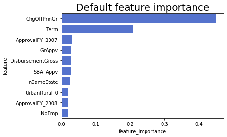

```python
var_imp_plot(base_imp,'Default feature importance')
```

According to the graph above, the ChgOffPrinGr, Term, and ApprovalFY are the tope 3 most important features.

Verify Extra Tree with 10-fold cross validation

```python
scores = cross_val_score(clf_xdt, x_train, y_train, cv=10)
print("Cross Validation Score for each K",scores)
clf_xdt_cv = round((scores.mean()*100),2)
print('Average Accuracy Rate: ', round((scores.mean()*100),1),'%')
```

```
Cross Validation Score for each K [0.9878269  0.98738921 0.9873068  0.98645876 0.98711531 0.98856518
 0.98812748 0.98837368 0.98777185 0.98782656]
Average Accuracy Rate:  98.8 %
```

To prevent overfitting, I applied cross validation to the Extra Tree model. After cross validation, the average accuracy rate is 98.8%. This means the accuracy rate of 98.83% is not overfitting.

## Stacking

```python
from sklearn.linear_model import LogisticRegression
from sklearn.naive_bayes import GaussianNB
from sklearn.ensemble import RandomForestClassifier
from sklearn.ensemble import VotingClassifier
from sklearn.ensemble import AdaBoostClassifier
from sklearn.tree import DecisionTreeClassifier
from sklearn.preprocessing import StandardScaler
from sklearn.pipeline import make_pipeline


clf1 = GradientBoostingClassifier(random_state=123)
clf2 = RandomForestClassifier(random_state=123)
clf3 = ExtraTreesClassifier(random_state=123)

stacked_learner = VotingClassifier(estimators=[('gradientboosting',clf1),('randomforest',clf2),
                                               ('extratrees',clf3)],voting='hard')
for MV, label in zip([clf1, clf2, clf3, stacked_learner],
                     ['Gradient Boosting', 'Random Forest', 'ExtraTrees', 'Second Stage Learner']):
    scores2 = cross_val_score(MV, x_train, y_train, cv=5, scoring='accuracy')
    print("Accuracy: %0.2f (+/- %0.2f) [%s]" % (scores2.mean(), scores2.std(), label))
```

```
Accuracy: 0.99 (+/- 0.00) [Gradient Boosting]
Accuracy: 0.99 (+/- 0.00) [Random Forest]
Accuracy: 0.99 (+/- 0.00) [ExtraTrees]
Accuracy: 0.99 (+/- 0.00) [Second Stage Learner]
```

The accuracy of Stacking is 0.99, which is very high.

## ROC Curve

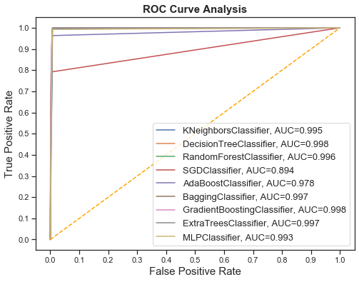

```python
from sklearn.metrics import roc_curve, roc_auc_score

# Instantiate the classfiers and make a list
classifiers = [KNeighborsClassifier(leaf_size=25, p=1, n_neighbors=27),
               DecisionTreeClassifier(ccp_alpha=0.0, class_weight=None, criterion='gini',
                                      max_depth=4, max_features=None, max_leaf_nodes=None,
                                      min_impurity_decrease=0.0, min_impurity_split=None,
                                      min_samples_leaf=1, min_samples_split=2,
                                      min_weight_fraction_leaf=0.0, presort='deprecated',
                                      random_state=None, splitter='best'),
               RandomForestClassifier(class_weight='balanced',random_state=123,max_depth=8, min_samples_leaf=1,
                                      min_samples_split=2, n_estimators=1200),
               SGDClassifier(loss='modified_huber', learning_rate = 'adaptive', eta0 = 100,
                             class_weight = {1: 0.4, 0: 0.6}, alpha=0.1, random_state=0, penalty='elasticnet'),
               AdaBoostClassifier(DecisionTreeClassifier(class_weight='balanced'),algorithm="SAMME.R",
                                  n_estimators=1000, learning_rate=0.1, random_state=123),
               BaggingClassifier(DecisionTreeClassifier(max_depth=5),max_samples = 0.2, max_features = 0.6),
               GradientBoostingClassifier(n_estimators = 60,learning_rate=0.2, min_samples_split=800,
                                          min_samples_leaf=50,
                                          max_depth=5,max_features='sqrt',subsample=0.8,random_state=123),
               ExtraTreesClassifier(n_estimators=60, n_jobs=4, min_samples_split=25,
                            min_samples_leaf=35, max_features=20, random_state=123),
               MLPClassifier(activation= 'logistic', hidden_layer_sizes=(10,10),
                       solver="adam", learning_rate="constant", max_iter=1000,random_state=0)]

# Define a result table as a DataFrame
result_table = pd.DataFrame(columns=['classifiers', 'fpr','tpr','auc'])

# Train the models and record the results
for cls in classifiers:
    model = cls.fit(x_train, y_train)
    target_predicted = model.predict_proba(x_test)[::,1]

    fpr, tpr, _ = roc_curve(y_test,  target_predicted)
    auc = roc_auc_score(y_test, target_predicted)

    result_table = result_table.append({'classifiers':cls.__class__.__name__,
                                        'fpr':fpr,
                                        'tpr':tpr,
                                        'auc':auc}, ignore_index=True)

# Set name of the classifiers as index labels
result_table.set_index('classifiers', inplace=True)


fig = plt.figure(figsize=(8,6))

for i in result_table.index:
    plt.plot(result_table.loc[i]['fpr'],
             result_table.loc[i]['tpr'],
             label="{}, AUC={:.3f}".format(i, result_table.loc[i]['auc']))

plt.plot([0,1], [0,1], color='orange', linestyle='--')

plt.xticks(np.arange(0.0, 1.1, step=0.1))
plt.xlabel("False Positive Rate", fontsize=15)

plt.yticks(np.arange(0.0, 1.1, step=0.1))
plt.ylabel("True Positive Rate", fontsize=15)

plt.title('ROC Curve Analysis', fontweight='bold', fontsize=15)
plt.legend(prop={'size':13}, loc='lower right')

plt.show()
```

# Summary

### Analysis Matric

I used 10 prediction models in this notbook and get the result table below.

Table 1. Prediction Results

[output not shown]

When I look into the prediction results, the most important matric I was looking for is recall rate. My emphasis is to see the charged-off loans that has not been predicted rightly, which is the smaller the better. This could be calculated by the formular (1- recall rate). In another word, I was looking for the biggest recall rate. In addition to recall rate, accuracy rate and precision are considerred either.

### Cross Validation

I also checked if the models are overfitting. As the recall rate, accuracy rate is very high, this may result from overfitting. I used cross validation to test the overfitting. Cross validation could give an insight on how well the prediction model perform with unknow dataset (Wikipedia). The average accuracy rates of cross validation are almost the same with the prediction accuracy rate.

Table 2. Difference between Cross Validation and Accuracy Rates of Models

[output not shown]

In the difference column of Table 2, we can see the difference between models’ accuracy rate and cross validation. The differences are less than 0.1%, which are every small. So that the prediction results are not overfitting.

### Feature Importance

The important feature (Table 3) shows how important the features when predict the default status.

Table 3. Feature Importance (Random Forest)

[output not shown]

The most important feature is ChgOffPrinCr (charged-off amount), the feature importance of which is 0.62. The second important feature is Term(loan term in months) , the feature importance of which is 0.2. The importance of the rest features is less than 0.03. As we emphasis on the prediction of charged-off loans, it is reasonable to have charged-off amount as the most important feature.

## Additional Analysis

To check the influence of certain feature changes on accuracy rate. I run the ramdom forest model without ChgOffPrinGr and Term in the models below.

### Without ChgOffPrinGr

```python
SBA.drop(columns=['ChgOffPrinGr'], inplace=True)
print(SBA.columns)
```

```
Index(['MIS_Status', 'Term', 'NoEmp', 'NewExist', 'CreateJob', 'RetainedJob',
       'FranchiseCode', 'RevLineCr', 'LowDoc', 'DisbursementGross',
       'BalanceGross', 'GrAppv', 'SBA_Appv', 'InSameState', 'RealEstate',
       'Industry_Accom/Food_serv', 'Industry_Admin_sup/Waste_Mgmt_Rem',
       'Industry_Ag/For/Fish/Hunt', 'Industry_Arts/Entertain/Rec',
       'Industry_Construction', 'Industry_Educational',
       'Industry_Finance/Insurance', 'Industry_Healthcare/Social_assist',
       'Industry_Information', 'Industry_Manufacturing', 'Industry_Mgmt_comp',
       'Industry_Min/Quar/Oil_Gas_ext', 'Industry_Other_no_pub',
       'Industry_Prof/Science/Tech', 'Industry_Public_Admin',
       'Industry_RE/Rental/Lease', 'Industry_Retail_trade',
       'Industry_Trans/Ware', 'Industry_Utilities', 'Industry_Wholesale_trade',
       'ApprovalFY_1984', 'ApprovalFY_1987', 'ApprovalFY_1988',
       'ApprovalFY_1989', 'ApprovalFY_1990', 'ApprovalFY_1991',
       'ApprovalFY_1992', 'ApprovalFY_1993', 'ApprovalFY_1994',
       'ApprovalFY_1996', 'ApprovalFY_1997', 'ApprovalFY_1998',
       'ApprovalFY_1999', 'ApprovalFY_2000', 'ApprovalFY_2001',
       'ApprovalFY_2002', 'ApprovalFY_2003', 'ApprovalFY_2004',
       'ApprovalFY_2005', 'ApprovalFY_2006', 'ApprovalFY_2007',
       'ApprovalFY_2008', 'ApprovalFY_2009', 'ApprovalFY_2010',
       'ApprovalFY_2011', 'ApprovalFY_2012', 'ApprovalFY_2013',
       'ApprovalFY_2014', 'ApprovalFY_1994', 'ApprovalFY_1995',
       'ApprovalFY_1996', 'ApprovalFY_2004', 'ApprovalFY_2005', 'UrbanRural_0',
       'UrbanRural_1', 'UrbanRural_2'],
      dtype='object')
```

In order to see how the model will perform, I removed the colum ChgOffPrinGr to see how the model will perform.

```python
# Establish target and feature fields
from sklearn.model_selection import train_test_split
from sklearn.preprocessing import StandardScaler

x = SBA.iloc[:,1:]
y = SBA.iloc[:,0].values

# Scale the feature values prior to modeling
scale = StandardScaler()
x_s = scale.fit_transform(x)

x_train, x_test, y_train, y_test = train_test_split(x_s, y, test_size=0.20, random_state=0)

print(x_train.shape)
print(x_test.shape)
print(y_train.shape)
print(y_test.shape)
```

```
(365552, 70)
(91388, 70)
(365552,)
(91388,)
```

### Random Forest

```python
from sklearn.ensemble import RandomForestClassifier
#Build
clf_rf = RandomForestClassifier(class_weight='balanced', max_features='auto', n_estimators=100, random_state=123)
#max_features = 'auto' for default. Calculated as square root of number of features.
print(clf_rf)
#Train
clf_rf.fit(x_train, y_train)
#Validate
target_predicted = clf_rf.predict(x_test)
print("Random Forfest Accuracy", accuracy_score(y_test, target_predicted))
target_names = ['0', '1']
print(classification_report(y_test, target_predicted, target_names=target_names))

# Confusion Matrix
print('Confusion Matrix: ')
print(confusion_matrix(y_test, target_predicted))

#extracting true_positives, false_positives, true_negatives, false_negatives
tn, fp, fn, tp = confusion_matrix(y_test, target_predicted).ravel()
print("True Negatives: ",tn)
print("False Positives: ",fp)
print("False Negatives: ",fn)
print("True Positives: ",tp)
```

```
RandomForestClassifier(bootstrap=True, ccp_alpha=0.0, class_weight='balanced',
                       criterion='gini', max_depth=None, max_features='auto',
                       max_leaf_nodes=None, max_samples=None,
                       min_impurity_decrease=0.0, min_impurity_split=None,
                       min_samples_leaf=1, min_samples_split=2,
                       min_weight_fraction_leaf=0.0, n_estimators=100,
                       n_jobs=None, oob_score=False, random_state=123,
                       verbose=0, warm_start=False)
Random Forfest Accuracy 0.9349695802512364
              precision    recall  f1-score   support

           0       0.95      0.97      0.96     71742
           1       0.88      0.80      0.84     19646

    accuracy                           0.93     91388
   macro avg       0.92      0.89      0.90     91388
weighted avg       0.93      0.93      0.93     91388

Confusion Matrix:
[[69693  2049]
 [ 3894 15752]]
True Negatives:  69693
False Positives:  2049
False Negatives:  3894
True Positives:  15752
```

```python
print('Training Score: {:.2f} \nTest Score: {:.2f}'.format(clf_rf.score(x_train, y_train),
                                                                 clf_rf.score(x_test, y_test)))
```

```
Training Score: 1.00
Test Score: 0.93
```

```python
base_imp = imp_df(x.columns, clf_rf.feature_importances_).head(10)
base_imp
```

|  | feature | feature_importance |
| --- | --- | --- |
| 0 | Term | 0.460663 |
| 1 | SBA_Appv | 0.064513 |
| 2 | DisbursementGross | 0.061157 |
| 3 | GrAppv | 0.049338 |
| 4 | RetainedJob | 0.039520 |
| 5 | NoEmp | 0.037667 |
| 6 | InSameState | 0.030362 |
| 7 | UrbanRural_0 | 0.029801 |
| 8 | CreateJob | 0.018446 |
| 9 | ApprovalFY_2007 | 0.017977 |

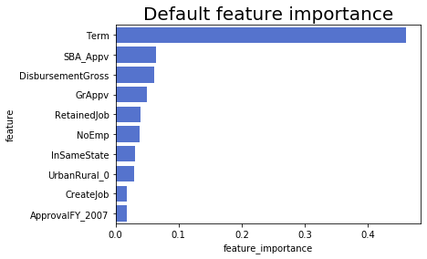

```python
var_imp_plot(base_imp,'Default feature importance')
```

After remove the ChgOffPrinGr, the accuracy rate of the Random Forest model decreased from 0.99 to 0.93. From the default feature importance graph, we can see that the most important feature changed to Term.

### Without ChgOffPrinGr and Term

```python
SBA.drop(columns=['Term'], inplace=True)
print(SBA.columns)
```

```
Index(['MIS_Status', 'NoEmp', 'NewExist', 'CreateJob', 'RetainedJob',
       'FranchiseCode', 'RevLineCr', 'LowDoc', 'DisbursementGross',
       'BalanceGross', 'GrAppv', 'SBA_Appv', 'InSameState', 'RealEstate',
       'Industry_Accom/Food_serv', 'Industry_Admin_sup/Waste_Mgmt_Rem',
       'Industry_Ag/For/Fish/Hunt', 'Industry_Arts/Entertain/Rec',
       'Industry_Construction', 'Industry_Educational',
       'Industry_Finance/Insurance', 'Industry_Healthcare/Social_assist',
       'Industry_Information', 'Industry_Manufacturing', 'Industry_Mgmt_comp',
       'Industry_Min/Quar/Oil_Gas_ext', 'Industry_Other_no_pub',
       'Industry_Prof/Science/Tech', 'Industry_Public_Admin',
       'Industry_RE/Rental/Lease', 'Industry_Retail_trade',
       'Industry_Trans/Ware', 'Industry_Utilities', 'Industry_Wholesale_trade',
       'ApprovalFY_1984', 'ApprovalFY_1987', 'ApprovalFY_1988',
       'ApprovalFY_1989', 'ApprovalFY_1990', 'ApprovalFY_1991',
       'ApprovalFY_1992', 'ApprovalFY_1993', 'ApprovalFY_1994',
       'ApprovalFY_1996', 'ApprovalFY_1997', 'ApprovalFY_1998',
       'ApprovalFY_1999', 'ApprovalFY_2000', 'ApprovalFY_2001',
       'ApprovalFY_2002', 'ApprovalFY_2003', 'ApprovalFY_2004',
       'ApprovalFY_2005', 'ApprovalFY_2006', 'ApprovalFY_2007',
       'ApprovalFY_2008', 'ApprovalFY_2009', 'ApprovalFY_2010',
       'ApprovalFY_2011', 'ApprovalFY_2012', 'ApprovalFY_2013',
       'ApprovalFY_2014', 'ApprovalFY_1994', 'ApprovalFY_1995',
       'ApprovalFY_1996', 'ApprovalFY_2004', 'ApprovalFY_2005', 'UrbanRural_0',
       'UrbanRural_1', 'UrbanRural_2'],
      dtype='object')
```

```python
# Establish target and feature fields
from sklearn.model_selection import train_test_split
from sklearn.preprocessing import StandardScaler

x = SBA.iloc[:,1:]
y = SBA.iloc[:,0].values

# Scale the feature values prior to modeling
scale = StandardScaler()
x_s = scale.fit_transform(x)

x_train, x_test, y_train, y_test = train_test_split(x_s, y, test_size=0.20, random_state=0)

print(x_train.shape)
print(x_test.shape)
print(y_train.shape)
print(y_test.shape)
```

```
(365552, 69)
(91388, 69)
(365552,)
(91388,)
```

```python
from sklearn.ensemble import RandomForestClassifier
#Build
clf_rf = RandomForestClassifier(class_weight='balanced', max_features='auto', n_estimators=100, random_state=123)
#max_features = 'auto' for default. Calculated as square root of number of features.
print(clf_rf)
#Train
clf_rf.fit(x_train, y_train)
#Validate
target_predicted = clf_rf.predict(x_test)
print("Random Forfest Accuracy", accuracy_score(y_test, target_predicted))
target_names = ['0', '1']
print(classification_report(y_test, target_predicted, target_names=target_names))

# Confusion Matrix
print('Confusion Matrix: ')
print(confusion_matrix(y_test, target_predicted))

#extracting true_positives, false_positives, true_negatives, false_negatives
tn, fp, fn, tp = confusion_matrix(y_test, target_predicted).ravel()
print("True Negatives: ",tn)
print("False Positives: ",fp)
print("False Negatives: ",fn)
print("True Positives: ",tp)
```

```
RandomForestClassifier(bootstrap=True, ccp_alpha=0.0, class_weight='balanced',
                       criterion='gini', max_depth=None, max_features='auto',
                       max_leaf_nodes=None, max_samples=None,
                       min_impurity_decrease=0.0, min_impurity_split=None,
                       min_samples_leaf=1, min_samples_split=2,
                       min_weight_fraction_leaf=0.0, n_estimators=100,
                       n_jobs=None, oob_score=False, random_state=123,
                       verbose=0, warm_start=False)
Random Forfest Accuracy 0.7962642797741498
              precision    recall  f1-score   support

           0       0.84      0.91      0.88     71742
           1       0.54      0.38      0.44     19646

    accuracy                           0.80     91388
   macro avg       0.69      0.64      0.66     91388
weighted avg       0.78      0.80      0.78     91388

Confusion Matrix:
[[65371  6371]
 [12248  7398]]
True Negatives:  65371
False Positives:  6371
False Negatives:  12248
True Positives:  7398
```

```python
print('Training Score: {:.2f} \nTest Score: {:.2f}'.format(clf_rf.score(x_train, y_train),
                                                                 clf_rf.score(x_test, y_test)))
```

```
Training Score: 0.98
Test Score: 0.80
```

```python
base_imp = imp_df(x.columns, clf_rf.feature_importances_).head(10)
base_imp
```

|  | feature | feature_importance |
| --- | --- | --- |
| 0 | DisbursementGross | 0.185766 |
| 1 | SBA_Appv | 0.108877 |
| 2 | NoEmp | 0.095691 |
| 3 | GrAppv | 0.093763 |
| 4 | RetainedJob | 0.085169 |
| 5 | CreateJob | 0.047392 |
| 6 | InSameState | 0.034128 |
| 7 | UrbanRural_0 | 0.032201 |
| 8 | ApprovalFY_2007 | 0.025927 |
| 9 | RealEstate | 0.021628 |

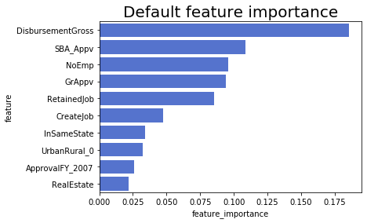

```python
var_imp_plot(base_imp,'Default feature importance')
```

After remove ChgOffPrinGr and Term, the accuracy rate of the Random Forest model decreased from 0.93 to 0.80. From the default feature importance graph, we can see that the most important feature changed to DisbursementGross.